# 化妆品商户销售数据分析

## 项目背景

为提高店铺的收益，进行准确的客户运营策略，使用kaggle提供的某化妆品电商2019年10月至2020年02月的销售数据进行分析。 根据网站流量数据、客户转化率数据、客户消费趋势、消费习惯把握客户的消费现状和心理，并进行新老顾客划分以及基于KMeans方法实现的RFM模型的客户分群，挖掘出高价值用户群体，完善销售运营策略。

## 准备阶段

### Standard Imports

```python
from datetime import datetime
import numpy as np
import pandas as pd
import matplotlib.pyplot as plt
import seaborn as sns
from scipy import stats
from matplotlib.ticker import FuncFormatter
import os
import inspect

from IPython.display import HTML  # 数据介绍时不显示index
```

```python
# plt.rcParams.update(plt.rcParamsDefault)
# mac系统解决中文乱码
plt.rcParams['font.sans-serif'] = ['Arial Unicode MS']
plt.rcParams['axes.unicode_minus'] = False

plt.style.available
style = 'tableau-colorblind10'   # 结合tableau，出于一致性使用tableau-colorblind10
sns.set_style('darkgrid')
# plt.style.available
```

### 连接数据库

出于一致性，将使用`ipython-sql`组件直接在jupyter notebook中调用sql语句

```python
# pip install ipython-sql
%load_ext sql
```

```python
%sql mysql+pymysql: // root: wzz990506@localhost/cosmetic_e_commerce
```

```python
% % sql
show tables
```

```
 * mysql+pymysql://root:***@localhost/cosmetic_e_commerce
1 rows affected.
```

| Tables_in_cosmetic_e_commerce |
| --- |
| cosmetic |

## 数据集介绍

数据集来自于kaggle公开数据集，包含了某电商网站中一家化妆品商户的**20M**条用户行为数据。 https://www.kaggle.com/mkechinov/ecommerce-events-history-in-cosmetics-shop

**字段描述**

| 属性 | 描述 |
| --- | --- |
| event_time | 事件发生的UTC时间 |
| event_type | 事件类型 |
| product_id | 商品ID |
| category_id | 商品类别ID |
| category_code | 商品类目，通常只存在在有意义的类别中，跳过配件以及附属品 |
| brand | 小写字母的品牌名称，可能缺失 |
| price | 商品价格 |
| user_id | 永久用户ID |
| user_session | 暂时用户ID |

**Event types**

Events can be:

```
view - a user viewed a product
cart - a user added a product to shopping cart
remove_from_cart - a user removed a product from shopping cart
purchase - a user purchased a product
```

**Multiple purchases per session**

A session can have multiple purchase events. It's ok, because it's a single order.

## 数据探查

```python
print(os.listdir('./archive/'))
```

```
['2020-Jan.csv', '2019-Dec.csv', '2020-Feb.csv', '2019-Nov.csv', '2019-Oct.csv']
```

```python
df = pd.DataFrame()
for file in os.listdir('./archive'):
    df = pd.concat([df, pd.read_csv(os.path.join('./archive', file))])
df = df.reset_index(drop=True)
df.head()
```

|  | event_time | event_type | product_id | category_id | category_code | brand | price | user_id | user_session |
| --- | --- | --- | --- | --- | --- | --- | --- | --- | --- |
| 0 | 2020-01-01 00:00:00 UTC | view | 5809910 | 1602943681873052386 | NaN | grattol | 5.24 | 595414620 | 4adb70bb-edbd-4981-b60f-a05bfd32683a |
| 1 | 2020-01-01 00:00:09 UTC | view | 5812943 | 1487580012121948301 | NaN | kinetics | 3.97 | 595414640 | c8c5205d-be43-4f1d-aa56-4828b8151c8a |
| 2 | 2020-01-01 00:00:19 UTC | view | 5798924 | 1783999068867920626 | NaN | zinger | 3.97 | 595412617 | 46a5010f-bd69-4fbe-a00d-bb17aa7b46f3 |
| 3 | 2020-01-01 00:00:24 UTC | view | 5793052 | 1487580005754995573 | NaN | NaN | 4.92 | 420652863 | 546f6af3-a517-4752-a98b-80c4c5860711 |
| 4 | 2020-01-01 00:00:25 UTC | view | 5899926 | 2115334439910245200 | NaN | NaN | 3.92 | 484071203 | cff70ddf-529e-4b0c-a4fc-f43a749c0acb |

```python
df.shape
```

```
(20692840, 9)
```

```python
df.info(null_counts=True)
```

```
<class 'pandas.core.frame.DataFrame'>
RangeIndex: 20692840 entries, 0 to 20692839
Data columns (total 9 columns):
 #   Column         Non-Null Count     Dtype
---  ------         --------------     -----
 0   event_time     20692840 non-null  object
 1   event_type     20692840 non-null  object
 2   product_id     20692840 non-null  int64
 3   category_id    20692840 non-null  int64
 4   category_code  353594 non-null    object
 5   brand          11935723 non-null  object
 6   price          20692840 non-null  float64
 7   user_id        20692840 non-null  int64
 8   user_session   20688242 non-null  object
dtypes: float64(1), int64(3), object(5)
memory usage: 1.4+ GB
```

```python
df.describe(include='all')
```

|  | event_time | event_type | product_id | category_id | category_code | brand | price | user_id | user_session |
| --- | --- | --- | --- | --- | --- | --- | --- | --- | --- |
| count | 20692840 | 20692840 | 2.069284e+07 | 2.069284e+07 | 353594 | 11935723 | 2.069284e+07 | 2.069284e+07 | 20688242 |
| unique | 8782890 | 4 | NaN | NaN | 12 | 273 | NaN | NaN | 4535941 |
| top | 2020-02-15 16:08:37 UTC | view | NaN | NaN | appliances.environment.vacuum | runail | NaN | NaN | 74206ba1-c863-4760-bbdc-b11777059e46 |
| freq | 3087 | 9657821 | NaN | NaN | 149168 | 1528908 | NaN | NaN | 5411 |
| mean | NaN | NaN | 5.484297e+06 | 1.554230e+18 | NaN | NaN | 8.534735e+00 | 5.215527e+08 | NaN |
| std | NaN | NaN | 1.305716e+06 | 1.691038e+17 | NaN | NaN | 1.938142e+01 | 8.744312e+07 | NaN |
| min | NaN | NaN | 3.752000e+03 | 1.487580e+18 | NaN | NaN | -7.937000e+01 | 4.654960e+05 | NaN |
| 25% | NaN | NaN | 5.724650e+06 | 1.487580e+18 | NaN | NaN | 2.060000e+00 | 4.818306e+08 | NaN |
| 50% | NaN | NaN | 5.810720e+06 | 1.487580e+18 | NaN | NaN | 4.050000e+00 | 5.531297e+08 | NaN |
| 75% | NaN | NaN | 5.857864e+06 | 1.487580e+18 | NaN | NaN | 7.060000e+00 | 5.788573e+08 | NaN |
| max | NaN | NaN | 5.932595e+06 | 2.242903e+18 | NaN | NaN | 3.277800e+02 | 6.220902e+08 | NaN |

### 缺失情况探查

```python
df.isnull().any()
```

```
event_time       False
event_type       False
product_id       False
category_id      False
category_code     True
brand             True
price            False
user_id          False
user_session      True
dtype: bool
```

```python
df.isnull().sum()
```

```
event_time              0
event_type              0
product_id              0
category_id             0
category_code    20339246
brand             8757117
price                   0
user_id                 0
user_session         4598
dtype: int64
```

`category_code`和`brand`以及`user_session`有缺失

```python
missing_info = pd.DataFrame(
    columns=['Miss_Value_Counts', 'Miss_Value_Precentage'])
missing_info['Miss_Value_Counts'] = [sum(df.category_code.isnull()), sum(
    df.brand.isnull()), sum(df.user_session.isnull())]
missing_info['Miss_Value_Precentage'] = missing_info['Miss_Value_Counts']/df.shape[0]
missing_info.index = ['category_code', 'brand', 'user_session']
missing_info
```

|  | Miss_Value_Counts | Miss_Value_Precentage |
| --- | --- | --- |
| category_code | 20339246 | 0.982912 |
| brand | 8757117 | 0.423196 |
| user_session | 4598 | 0.000222 |

`category_code`和`brand`删失率很高，但这两个字段并不容易填充，也不能去除，暂时不处理

### 异常值检查

```python
df['price'].describe()
```

```
count    2.069284e+07
mean     8.534735e+00
std      1.938142e+01
min     -7.937000e+01
25%      2.060000e+00
50%      4.050000e+00
75%      7.060000e+00
max      3.277800e+02
Name: price, dtype: float64
```

可以看出`price`的最小值为负数，不符合实际情况，需要进行修正

## 数据预处理

### 去除重复行

```python
# 去除重复行
df.drop_duplicates(inplace=True)
```

```python
df.info()
```

```
<class 'pandas.core.frame.DataFrame'>
Int64Index: 19583742 entries, 0 to 20692839
Data columns (total 9 columns):
 #   Column         Dtype
---  ------         -----
 0   event_time     object
 1   event_type     object
 2   product_id     int64
 3   category_id    int64
 4   category_code  object
 5   brand          object
 6   price          float64
 7   user_id        int64
 8   user_session   object
dtypes: float64(1), int64(3), object(5)
memory usage: 1.5+ GB
```

```python
print('共 {} 条重复记录'.format(20692840-19583742))
```

```
共 1109098 条重复记录
```

### 异常值处理

```python
df.price = df.price.apply(lambda x: 0 if x < 0 else x)
df.price.describe()
```

```
count    1.958374e+07
mean     8.740125e+00
std      1.976346e+01
min      0.000000e+00
25%      2.100000e+00
50%      4.110000e+00
75%      7.140000e+00
max      3.277800e+02
Name: price, dtype: float64
```

```python
df.head()
```

|  | event_time | event_type | product_id | category_id | category_code | brand | price | user_id | user_session |
| --- | --- | --- | --- | --- | --- | --- | --- | --- | --- |
| 0 | 2020-01-01 00:00:00 UTC | view | 5809910 | 1602943681873052386 | NaN | grattol | 5.24 | 595414620 | 4adb70bb-edbd-4981-b60f-a05bfd32683a |
| 1 | 2020-01-01 00:00:09 UTC | view | 5812943 | 1487580012121948301 | NaN | kinetics | 3.97 | 595414640 | c8c5205d-be43-4f1d-aa56-4828b8151c8a |
| 2 | 2020-01-01 00:00:19 UTC | view | 5798924 | 1783999068867920626 | NaN | zinger | 3.97 | 595412617 | 46a5010f-bd69-4fbe-a00d-bb17aa7b46f3 |
| 3 | 2020-01-01 00:00:24 UTC | view | 5793052 | 1487580005754995573 | NaN | NaN | 4.92 | 420652863 | 546f6af3-a517-4752-a98b-80c4c5860711 |
| 4 | 2020-01-01 00:00:25 UTC | view | 5899926 | 2115334439910245200 | NaN | NaN | 3.92 | 484071203 | cff70ddf-529e-4b0c-a4fc-f43a749c0acb |

### 提取时间

```python
df['event_time'].str.index(' ')
```

```
0           10
1           10
2           10
3           10
4           10
            ..
20692835    10
20692836    10
20692837    10
20692838    10
20692839    10
Name: event_time, Length: 19583742, dtype: int64
```

```python
df['event_time'].str.index(' ', 11)
```

```
0           19
1           19
2           19
3           19
4           19
            ..
20692835    19
20692836    19
20692837    19
20692838    19
20692839    19
Name: event_time, Length: 19583742, dtype: int64
```

```python
df['event_time'].str[:19]
```

```
0           2020-01-01 00:00:00
1           2020-01-01 00:00:09
2           2020-01-01 00:00:19
3           2020-01-01 00:00:24
4           2020-01-01 00:00:25
                   ...
20692835    2019-10-31 23:59:25
20692836    2019-10-31 23:59:30
20692837    2019-10-31 23:59:34
20692838    2019-10-31 23:59:36
20692839    2019-10-31 23:59:54
Name: event_time, Length: 19583742, dtype: object
```

```python
# 去掉event_time中的UTC
df.event_time = df['event_time'].str[:19]
```

```python
# df.head()
# 提取月份，日期，时间，小时
df['year_month'] = df.event_time.apply(
    lambda x: '-'.join((x.split('-')[0], x.split('-')[1])))
df['time'] = df.event_time.apply(lambda x: x.split(' ')[1])
df['date'] = df.event_time.apply(lambda x: x.split(' ')[0])
df['hour'] = df.event_time.apply(lambda x: (x.split(' ')[1]).split(':')[0])
```

```python
df.tail()
```

|  | event_time | event_type | product_id | category_id | category_code | brand | price | user_id | user_session | year_month | time | date | hour |
| --- | --- | --- | --- | --- | --- | --- | --- | --- | --- | --- | --- | --- | --- |
| 20692835 | 2019-10-31 23:59:25 | remove_from_cart | 5848062 | 1526733091857498510 | NaN | NaN | 9.21 | 429913900 | 2f0bff3c-252f-4fe6-afcd-5d8a6a92839a | 2019-10 | 23:59:25 | 2019-10-31 | 23 |
| 20692836 | 2019-10-31 23:59:30 | view | 5885631 | 1783999064103190764 | NaN | NaN | 15.48 | 556138645 | 57ed222e-a54a-4907-9944-5a875c2d7f4f | 2019-10 | 23:59:30 | 2019-10-31 | 23 |
| 20692837 | 2019-10-31 23:59:34 | view | 5784898 | 1487580009143992338 | NaN | NaN | 1.78 | 564441099 | 8cbf1746-2d46-4169-afb1-b5fa38ee1ba4 | 2019-10 | 23:59:34 | 2019-10-31 | 23 |
| 20692838 | 2019-10-31 23:59:36 | view | 5870838 | 1487580007675986893 | NaN | milv | 0.79 | 429913900 | 2f0bff3c-252f-4fe6-afcd-5d8a6a92839a | 2019-10 | 23:59:36 | 2019-10-31 | 23 |
| 20692839 | 2019-10-31 23:59:54 | view | 59996 | 1487580012927254698 | NaN | NaN | 4.13 | 566280798 | 4eaf7c71-e8bf-4ea6-b719-eca144466eb3 | 2019-10 | 23:59:54 | 2019-10-31 | 23 |

### 抽样 & 导出

由于数据量太大，tableau和sql都不支持，在此随机抽取20%的数据

```python
df_sampled = df.sample(frac=0.2)
df_sampled.info()
```

```
<class 'pandas.core.frame.DataFrame'>
Int64Index: 3916748 entries, 11916962 to 18662611
Data columns (total 13 columns):
 #   Column         Dtype
---  ------         -----
 0   event_time     object
 1   event_type     object
 2   product_id     int64
 3   category_id    int64
 4   category_code  object
 5   brand          object
 6   price          float64
 7   user_id        int64
 8   user_session   object
 9   year_month     object
 10  time           object
 11  date           object
 12  hour           object
dtypes: float64(1), int64(3), object(9)
memory usage: 418.4+ MB
```

导出预处理后的数据作为备份

```python
# df_sampled.to_csv('cosmetic.csv')
```

```python
df_sampled = pd.read_csv('cosmetic.csv')
```

## 电商网站页面浏览量分析

### 页面浏览量指标

```python
df_sampled.head()
```

|  | Unnamed: 0 | event_time | event_type | product_id | category_id | category_code | brand | price | user_id | user_session | year_month | time | date | hour |
| --- | --- | --- | --- | --- | --- | --- | --- | --- | --- | --- | --- | --- | --- | --- |
| 0 | 11916962 | 2020-02-29 18:09:12 | view | 5835336 | 1487580006962955182 | NaN | NaN | 3.17 | 536730333 | 1e3b5503-7642-4521-87f9-2c9c49b62aac | 2020-02 | 18:09:12 | 2020-02-29 | 18 |
| 1 | 9193049 | 2020-02-10 08:39:49 | view | 15191 | 1487580008447738866 | NaN | cnd | 9.00 | 559281525 | dccf51ec-85fa-444c-9f03-7b6af2a3ae0f | 2020-02 | 08:39:49 | 2020-02-10 | 8 |
| 2 | 6020658 | 2019-12-14 10:47:02 | view | 5828847 | 1487580011308253293 | NaN | mavala | 9.05 | 584659548 | 58f201f4-491e-41bc-84cf-93c0ab7b8f6b | 2019-12 | 10:47:02 | 2019-12-14 | 10 |
| 3 | 9996855 | 2020-02-15 19:38:21 | cart | 5841799 | 1487580009471148064 | NaN | NaN | 0.13 | 615451276 | a0386269-94ee-4026-9b5d-e33081835913 | 2020-02 | 19:38:21 | 2020-02-15 | 19 |
| 4 | 10352454 | 2020-02-18 10:00:16 | purchase | 5836357 | 1487580005008409427 | NaN | f.o.x | 4.83 | 613411696 | 3ee833ca-c12d-4b7f-b645-46a20a3dbfb0 | 2020-02 | 10:00:16 | 2020-02-18 | 10 |

```python
df_view = df_sampled[df_sampled['event_type'] == 'view']
df_view
```

|  | Unnamed: 0 | event_time | event_type | product_id | category_id | category_code | brand | price | user_id | user_session | year_month | time | date | hour |
| --- | --- | --- | --- | --- | --- | --- | --- | --- | --- | --- | --- | --- | --- | --- |
| 0 | 11916962 | 2020-02-29 18:09:12 | view | 5835336 | 1487580006962955182 | NaN | NaN | 3.17 | 536730333 | 1e3b5503-7642-4521-87f9-2c9c49b62aac | 2020-02 | 18:09:12 | 2020-02-29 | 18 |
| 1 | 9193049 | 2020-02-10 08:39:49 | view | 15191 | 1487580008447738866 | NaN | cnd | 9.00 | 559281525 | dccf51ec-85fa-444c-9f03-7b6af2a3ae0f | 2020-02 | 08:39:49 | 2020-02-10 | 8 |
| 2 | 6020658 | 2019-12-14 10:47:02 | view | 5828847 | 1487580011308253293 | NaN | mavala | 9.05 | 584659548 | 58f201f4-491e-41bc-84cf-93c0ab7b8f6b | 2019-12 | 10:47:02 | 2019-12-14 | 10 |
| 6 | 14871824 | 2019-11-21 20:07:04 | view | 5863109 | 1487580011702517887 | NaN | elizavecca | 12.57 | 427566381 | 549c1bca-0582-4561-838c-b411533b671c | 2019-11 | 20:07:04 | 2019-11-21 | 20 |
| 12 | 12609911 | 2019-11-06 04:25:57 | view | 5851280 | 1525995662934540829 | NaN | NaN | 3.97 | 426491934 | a385e6ae-b0d1-4439-a55a-3b3923c92078 | 2019-11 | 04:25:57 | 2019-11-06 | 4 |
| ... | ... | ... | ... | ... | ... | ... | ... | ... | ... | ... | ... | ... | ... | ... |
| 3916737 | 17039917 | 2019-10-03 19:14:39 | view | 5857045 | 1487580005092295511 | NaN | runail | 4.44 | 438225640 | f84b8bf1-00bb-480c-8dbe-f10bd6e94aec | 2019-10 | 19:14:39 | 2019-10-03 | 19 |
| 3916740 | 8870509 | 2020-02-07 20:36:49 | view | 5921163 | 1597770225539875791 | NaN | bielenda | 4.76 | 609526240 | d6100b6c-a747-4940-ab8a-2c4b7244e721 | 2020-02 | 20:36:49 | 2020-02-07 | 20 |
| 3916743 | 17034078 | 2019-10-03 18:28:17 | view | 5726673 | 1487580009521479714 | NaN | NaN | 1.59 | 556483652 | bfb1a079-3d70-4925-b533-be2aeeb13fab | 2019-10 | 18:28:17 | 2019-10-03 | 18 |
| 3916744 | 17512193 | 2019-10-07 07:34:28 | view | 5857339 | 1487580005134238553 | NaN | runail | 2.78 | 557623404 | 3b9b4239-53eb-4156-b6ac-c37d6e50032a | 2019-10 | 07:34:28 | 2019-10-07 | 7 |
| 3916746 | 4241670 | 2020-01-31 19:19:35 | view | 5772475 | 1602943681873052386 | NaN | grattol | 4.76 | 550989800 | f064ee7e-27bd-4e5a-8f66-0259d9d1511e | 2020-01 | 19:19:35 | 2020-01-31 | 19 |

1932272 rows × 14 columns

```python
# 总页面浏览量，日均页面浏览量，日最大页面浏览量，日最小页面浏览量
# pv:page view
pv_all = df_view.shape[0]
pv_daily = df_view.date.value_counts()
pv_mean = np.mean(pv_daily)
pv_max = np.max(pv_daily)
pv_min = np.min(pv_daily)
```

浏览量前10的日期

```python
% % sql
SELECT date, COUNT(1) AS pv_daily
FROM cosmetic
WHERE event_type = 'view'
GROUP BY date
ORDER BY pv_daily DESC
LIMIT 10
```

```
 * mysql+pymysql://root:***@localhost/cosmetic_e_commerce
10 rows affected.
```

| date | pv_daily |
| --- | --- |
| 2019-11-22 | 22155 |
| 2019-11-28 | 19128 |
| 2019-11-21 | 17993 |
| 2020-01-27 | 17686 |
| 2019-11-29 | 17624 |
| 2019-11-24 | 17314 |
| 2019-11-23 | 17129 |
| 2020-01-28 | 16458 |
| 2020-02-03 | 16090 |
| 2019-11-07 | 15734 |

总浏览量

```python
% % sql
SELECT COUNT(1) AS pv_all
FROM cosmetic
WHERE event_type = 'view'
```

```
 * mysql+pymysql://root:***@localhost/cosmetic_e_commerce
1 rows affected.
```

| pv_all |
| --- |
| 1932272 |

日均页面浏览量

```python
% % sql
SELECT COUNT(1)/COUNT(DISTINCT date) AS pv_mean
FROM cosmetic
WHERE event_type = 'view'
```

```
 * mysql+pymysql://root:***@localhost/cosmetic_e_commerce
1 rows affected.
```

| pv_mean |
| --- |
| 12712.3158 |

日最小页面浏览量

```python
% % sql
SELECT date, COUNT(1) AS pv_min
FROM cosmetic
WHERE event_type = 'view'
GROUP BY date
ORDER BY pv_min
LIMIT 1
```

```
 * mysql+pymysql://root:***@localhost/cosmetic_e_commerce
1 rows affected.
```

| date | pv_min |
| --- | --- |
| 2019-12-31 | 3512 |

月浏览量

```python
% % sql
SELECT `year_month`, COUNT(1) AS pv_monthly
FROM cosmetic
WHERE event_type = 'view'
GROUP BY `year_month`
```

```
 * mysql+pymysql://root:***@localhost/cosmetic_e_commerce
5 rows affected.
```

| year_month | pv_monthly |
| --- | --- |
| 2020-02 | 391477 |
| 2019-12 | 345945 |
| 2019-11 | 415261 |
| 2019-10 | 372351 |
| 2020-01 | 407238 |

```python
pv_metrics = pd.DataFrame(pd.Series([pv_all, pv_mean, pv_max, pv_min], index=[
                          '总页面浏览量', '日均页面浏览量', '日最大页面浏览量', '日最小页面浏览量'], name='指标值'))

pv_metrics.astype('int').style.set_table_attributes(
    "style='display:inline'").set_caption('页面浏览量指标')
```

页面浏览量指标

|  | 指标值 |
| --- | --- |
| 总页面浏览量 | 1932272 |
| 日均页面浏览量 | 12712 |
| 日最大页面浏览量 | 22155 |
| 日最小页面浏览量 | 3512 |

### 日/月浏览量趋势

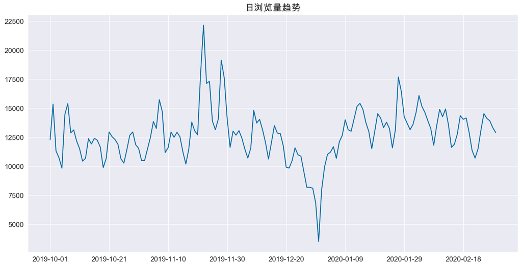

```python
plt.rcParams['font.sans-serif'] = ['Arial Unicode MS']
plt.rcParams['axes.unicode_minus'] = False

plt.figure(figsize=(15, 7.5), dpi=100)
plt.style.use(style)
plt.title('日浏览量趋势', size=16)

pv_daily.sort_index().plot()
plt.xticks(size=12)
plt.yticks(size=12)
```

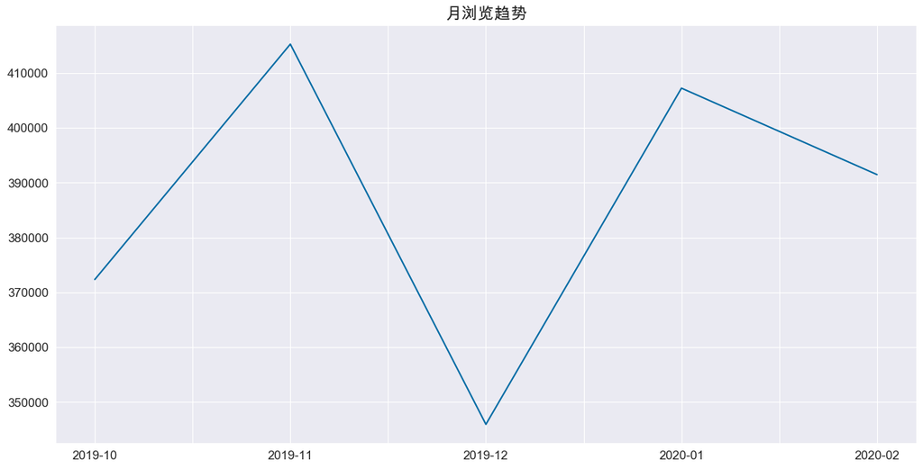

```python
pv_monthly = df_view.year_month.value_counts()
# pv_monthly
plt.figure(figsize=(15, 7.5), dpi=100)
plt.style.use(style)
pv_monthly.sort_index().plot()
plt.xticks(size=12)
plt.yticks(size=12)
plt.title('月浏览趋势', size=16)
```

```python
pv_monthly.index
```

```
Index(['2019-11', '2020-01', '2020-02', '2019-10', '2019-12'], dtype='object')
```

```python
nov = abs((pv_monthly['2019-11']/np.mean(pv_monthly[['2019-10',
                                                     '2020-01', '2020-02']])-1)*100).round(2)
dec = abs((pv_monthly['2019-12']/np.mean(pv_monthly[['2019-10',
                                                     '2020-01', '2020-02']])-1)*100).round(2)
```

```python
print(f'促销活动带来了比平时多{nov}%的流量')
print(f'而圣诞节期间快递以及其他基础设施停运造成的物流时效变长导致了比平常少{dec}%的流量')
```

```
促销活动带来了比平时多6.38%的流量
而圣诞节期间快递以及其他基础设施停运造成的物流时效变长导致了比平常少11.38%的流量
```

```python
pv_daily
```

```
2019-11-22    22155
2019-11-28    19128
2019-11-21    17993
2020-01-27    17686
2019-11-29    17624
              ...
2019-12-28     8186
2019-12-29     8110
2020-01-01     7943
2019-12-30     6838
2019-12-31     3512
Name: date, Length: 152, dtype: int64
```

```python
np.mean(pv_monthly)
```

```
386454.4
```

**结论**：

```
11月22日由于黑色星期五活动的原因，单日页面浏览量达到了五个月中的峰值，而在12月31日左右由于圣诞假期，快递停运等原因，页面浏览量达到了最低谷，符合预期。

体现在月度数据中即为十一月份电商网站的页面浏览量最高，而十二月份最低。其他月份则维持在380000上下的页面浏览量水平，较为稳定。
```

## 电商网站客户访问量水平

### 客户维度

```python
df_view.head()
```

|  | Unnamed: 0 | event_time | event_type | product_id | category_id | category_code | brand | price | user_id | user_session | year_month | time | date | hour |
| --- | --- | --- | --- | --- | --- | --- | --- | --- | --- | --- | --- | --- | --- | --- |
| 0 | 11916962 | 2020-02-29 18:09:12 | view | 5835336 | 1487580006962955182 | NaN | NaN | 3.17 | 536730333 | 1e3b5503-7642-4521-87f9-2c9c49b62aac | 2020-02 | 18:09:12 | 2020-02-29 | 18 |
| 1 | 9193049 | 2020-02-10 08:39:49 | view | 15191 | 1487580008447738866 | NaN | cnd | 9.00 | 559281525 | dccf51ec-85fa-444c-9f03-7b6af2a3ae0f | 2020-02 | 08:39:49 | 2020-02-10 | 8 |
| 2 | 6020658 | 2019-12-14 10:47:02 | view | 5828847 | 1487580011308253293 | NaN | mavala | 9.05 | 584659548 | 58f201f4-491e-41bc-84cf-93c0ab7b8f6b | 2019-12 | 10:47:02 | 2019-12-14 | 10 |
| 6 | 14871824 | 2019-11-21 20:07:04 | view | 5863109 | 1487580011702517887 | NaN | elizavecca | 12.57 | 427566381 | 549c1bca-0582-4561-838c-b411533b671c | 2019-11 | 20:07:04 | 2019-11-21 | 20 |
| 12 | 12609911 | 2019-11-06 04:25:57 | view | 5851280 | 1525995662934540829 | NaN | NaN | 3.97 | 426491934 | a385e6ae-b0d1-4439-a55a-3b3923c92078 | 2019-11 | 04:25:57 | 2019-11-06 | 4 |

```python
df_uv = df_view[['user_id', 'date', 'event_type']
                ].groupby(['user_id', 'date']).count()
df_uv.columns = ['count']
df_uv
```

| user_id | date | count |
| --- | --- | --- |
| 1458813 | 2019-11-20 | 5 |
| 2963072 | 2019-12-22 | 5 |
| 3571443 | 2020-02-26 | 1 |
| 4103071 | 2019-10-21 | 2 |
| 4230352 | 2020-02-21 | 1 |
| ... | ... | ... |
| 622087993 | 2020-02-29 | 1 |
| 622088654 | 2020-02-29 | 1 |
| 622089105 | 2020-02-29 | 1 |
| 622090014 | 2020-02-29 | 1 |
| 622090016 | 2020-02-29 | 1 |

987790 rows × 1 columns

```python
df_uv_count = df_uv.groupby(['user_id']).sum()
df_uv_count.sort_values(by='count', ascending=False)
```

| user_id | count |
| --- | --- |
| 527021202 | 4125 |
| 557616099 | 1937 |
| 583884978 | 1933 |
| 557956487 | 1433 |
| 550388516 | 1421 |
| ... | ... |
| 568247716 | 1 |
| 568247624 | 1 |
| 568247570 | 1 |
| 568247267 | 1 |
| 622090016 | 1 |

625312 rows × 1 columns

```python
df_uv.reset_index(inplace=True)
df_uv
```

|  | user_id | date | count |
| --- | --- | --- | --- |
| 0 | 1458813 | 2019-11-20 | 5 |
| 1 | 2963072 | 2019-12-22 | 5 |
| 2 | 3571443 | 2020-02-26 | 1 |
| 3 | 4103071 | 2019-10-21 | 2 |
| 4 | 4230352 | 2020-02-21 | 1 |
| ... | ... | ... | ... |
| 987785 | 622087993 | 2020-02-29 | 1 |
| 987786 | 622088654 | 2020-02-29 | 1 |
| 987787 | 622089105 | 2020-02-29 | 1 |
| 987788 | 622090014 | 2020-02-29 | 1 |
| 987789 | 622090016 | 2020-02-29 | 1 |

987790 rows × 3 columns

```python
df_uv_count.reset_index(inplace=True)
df_uv_count
```

|  | user_id | count |
| --- | --- | --- |
| 0 | 1458813 | 5 |
| 1 | 2963072 | 5 |
| 2 | 3571443 | 1 |
| 3 | 4103071 | 2 |
| 4 | 4230352 | 1 |
| ... | ... | ... |
| 625307 | 622087993 | 1 |
| 625308 | 622088654 | 1 |
| 625309 | 622089105 | 1 |
| 625310 | 622090014 | 1 |
| 625311 | 622090016 | 1 |

625312 rows × 2 columns

```python
len(df_uv['user_id'].unique())
```

```
625312
```

```python
% % sql
SELECT COUNT(DISTINCT user_id) AS user_num
FROM cosmetic
WHERE event_type = 'view'
```

```
 * mysql+pymysql://root:***@localhost/cosmetic_e_commerce
1 rows affected.
```

| user_num |
| --- |
| 625312 |

```python
% % sql
SELECT user_id, COUNT(1) AS view_count
FROM cosmetic
WHERE event_type = 'view'
GROUP BY user_id
ORDER BY 2 DESC
LIMIT 10
```

```
 * mysql+pymysql://root:***@localhost/cosmetic_e_commerce
10 rows affected.
```

| user_id | view_count |
| --- | --- |
| 527021202 | 4125 |
| 557616099 | 1937 |
| 583884978 | 1933 |
| 557956487 | 1433 |
| 550388516 | 1421 |
| 352394658 | 913 |
| 553753653 | 879 |
| 531900924 | 786 |
| 500927959 | 751 |
| 223293700 | 660 |

```python
print('在201910-202002期间，共有{}位客户访问该网站。'.format(len(df_uv['user_id'].unique())))
print('其中访问次数最多的用户为user_id={},访问了{}次。'.format(df_uv_count.loc[df_uv_count['count'].argmax()]['user_id'],
                                              df_uv_count['count'].max()))
print('结合前一部分计算的总页面浏览量为1932272次，可以计算出人均页面访问量为:%.2f次' % (1932272/625312))
```

```
在201910-202002期间，共有625312位客户访问该网站。
其中访问次数最多的用户为user_id=527021202,访问了4125次。
结合前一部分计算的总页面浏览量为1932272次，可以计算出人均页面访问量为:3.09次
```

```python
print('访问量排名前十的用户为：')
df_uv_count.sort_values(by='count', ascending=False).iloc[:10]
```

```
访问量排名前十的用户为：
```

|  | user_id | count |
| --- | --- | --- |
| 133172 | 527021202 | 4125 |
| 216261 | 557616099 | 1937 |
| 397946 | 583884978 | 1933 |
| 219984 | 557956487 | 1433 |
| 177635 | 550388516 | 1421 |
| 18468 | 352394658 | 913 |
| 186651 | 553753653 | 879 |
| 140931 | 531900924 | 786 |
| 103523 | 500927959 | 751 |
| 2167 | 223293700 | 660 |

```python
uv_count = df_uv_count['count'].copy()
uv_count = uv_count.loc[uv_count <= np.quantile(uv_count, 0.99)]
uv_count_sum = pd.DataFrame({'count': uv_count, 'cumsum': uv_count.cumsum()})
uv_count_sum
```

|  | count | cumsum |
| --- | --- | --- |
| 0 | 5 | 5 |
| 1 | 5 | 10 |
| 2 | 1 | 11 |
| 3 | 2 | 13 |
| 4 | 1 | 14 |
| ... | ... | ... |
| 625307 | 1 | 1517684 |
| 625308 | 1 | 1517685 |
| 625309 | 1 | 1517686 |
| 625310 | 1 | 1517687 |
| 625311 | 1 | 1517688 |

619122 rows × 2 columns

```python
# uv_count_sum.to_csv('uv_count_cumsum.csv')
```

```
为了更直观的分析客户访问量情况，我们将大于99分位数的访问量视为异常值。为避免极值影响分布图的展示，下图只展示小于99分位数的访问量情况。
```

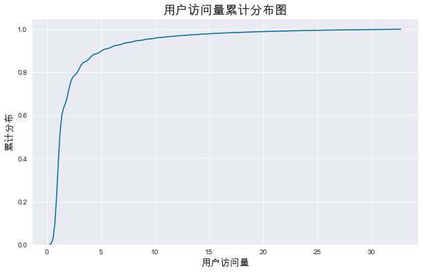

```python
print('为了更直观的分析客户访问量情况，我们将大于99分位数的访问量视为异常值。为避免极值影响分布图的展示，下图只展示小于99分位数的访问量情况。')
plt.figure(figsize=(10, 6))
plt.style.use(style)
sns.kdeplot(uv_count, cumulative=True)
plt.xlabel('用户访问量', size=14)
plt.ylabel('累计分布', size=14)
plt.title('用户访问量累计分布图', size=18)
```

### 时间维度：日/月客户量趋势

在此维度下，我们关注客户数量而非客户访问量，即：同一客户在一日之内访问多次仅算作一个客户。

```python
df_uv_date = df_uv[['user_id', 'date']]
df_uv_date['year_month'] = df_uv['date'].apply(lambda x: x[:7])
df_uv_date
```

|  | user_id | date | year_month |
| --- | --- | --- | --- |
| 0 | 1458813 | 2019-11-20 | 2019-11 |
| 1 | 2963072 | 2019-12-22 | 2019-12 |
| 2 | 3571443 | 2020-02-26 | 2020-02 |
| 3 | 4103071 | 2019-10-21 | 2019-10 |
| 4 | 4230352 | 2020-02-21 | 2020-02 |
| ... | ... | ... | ... |
| 987785 | 622087993 | 2020-02-29 | 2020-02 |
| 987786 | 622088654 | 2020-02-29 | 2020-02 |
| 987787 | 622089105 | 2020-02-29 | 2020-02 |
| 987788 | 622090014 | 2020-02-29 | 2020-02 |
| 987789 | 622090016 | 2020-02-29 | 2020-02 |

987790 rows × 3 columns

```python
uv_daily = df_uv_date.date.value_counts().sort_index()
uv_daily
```

```
2019-10-01    6467
2019-10-02    9436
2019-10-03    5800
2019-10-04    5364
2019-10-05    5085
              ...
2020-02-25    7314
2020-02-26    7109
2020-02-27    7271
2020-02-28    6791
2020-02-29    6722
Name: date, Length: 152, dtype: int64
```

```python
uv_monthly = df_uv_date.year_month.value_counts().sort_index()
uv_monthly
```

```
2019-10    193183
2019-11    200548
2019-12    183132
2020-01    209943
2020-02    200984
Name: year_month, dtype: int64
```

```python
print('日均客户量:', np.mean(uv_daily))
print('日最大客户量:{}, 日期为:{}'.format(max(uv_daily),
                                 uv_daily[uv_daily == max(uv_daily)].index[0]))
print('日最小客户量:{},日期为:{}'.format(min(uv_daily),
                                uv_daily[uv_daily == min(uv_daily)].index[0]))
```

```
日均客户量: 6498.618421052632
日最大客户量:9453, 日期为:2019-11-22
日最小客户量:2234,日期为:2019-12-31
```

日客户量最大的十天

```python
% % sql
SELECT date, COUNT(DISTINCT user_id) AS user_count
FROM cosmetic
WHERE event_type = 'view'
GROUP BY date
ORDER BY 2 DESC
LIMIT 10
```

```
 * mysql+pymysql://root:***@localhost/cosmetic_e_commerce
10 rows affected.
```

| date | user_count |
| --- | --- |
| 2019-11-22 | 9453 |
| 2019-10-02 | 9436 |
| 2019-10-06 | 8789 |
| 2019-11-28 | 8789 |
| 2019-10-07 | 8314 |
| 2020-01-27 | 8261 |
| 2020-02-03 | 8247 |
| 2020-02-02 | 8019 |
| 2019-11-29 | 7981 |
| 2020-01-14 | 7965 |

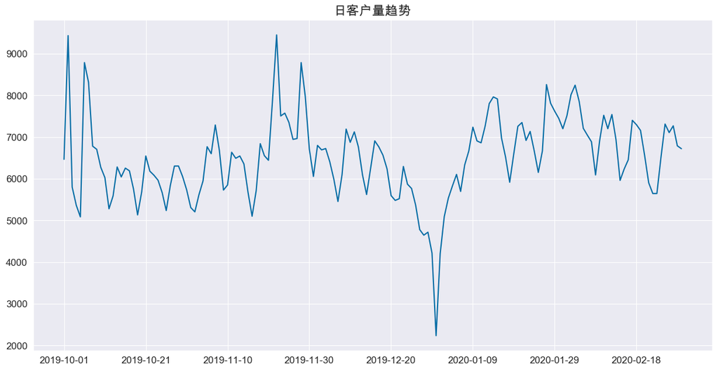

```python
plt.figure(figsize=(15, 7.5), dpi=100)
df_uv_date.date.value_counts().sort_index().plot()
plt.title('日客户量趋势', size=16)
plt.xticks(size=12)
plt.yticks(size=12)
```

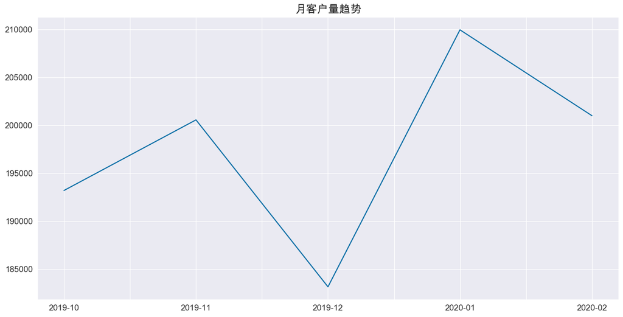

```python
plt.figure(figsize=(15, 7.5), dpi=100)
df_uv_date.year_month.value_counts().sort_index().plot()
plt.title('月客户量趋势', size=16)
plt.xticks(size=12)
plt.yticks(size=12)
```

联系上一部分的浏览量指标趋势，可以发现：

- 低谷都出现在12月31日，即圣诞节的放假效应使得客户浏览量和总浏览量都有明显下降，说明总浏览量下降应该是由客户量下降导致的。
- 高峰都出现在11月22日，若初步判断客户浏览量上升导致总浏览量上升有失偏颇，因为峰值的客户浏览量9453以极小的幅度高于10月2日的9436浏览量。在11月22日附近客户量增加，但是幅度并不明显。这说明黑色星期五的浏览量增加并非由于客户量上升导致，而是由于活动本身的运营策略导致存量客户的浏览增加。而十月初的时候，该平台可能采取了一些拉新的运营手段，吸引了大批新顾客，使得客户量量和总浏览量都有大幅度提升。
- 同时可以看到，十月的新用户运营策略持久性不长，十月出现了两次峰值后又回落至较低水平，导致十月的整体客户量并不高，不如2020年1月和2月。2020年1月可以看作是圣诞假期后的报复性消费期，然后到了二月自然回落，但二月仍然有着比2019年10月更高的水平。

## 漏斗模型：转化率分析

### 客户加购次数

```python
df_addcart = df_sampled[df_sampled.event_type == 'cart']
# df_addcart.head()
```

```python
df_addcart = df_addcart.drop(columns=df_addcart.columns[0])
df_addcart.head()
```

|  | event_time | event_type | product_id | category_id | category_code | brand | price | user_id | user_session | year_month | time | date | hour |
| --- | --- | --- | --- | --- | --- | --- | --- | --- | --- | --- | --- | --- | --- |
| 3 | 2020-02-15 19:38:21 | cart | 5841799 | 1487580009471148064 | NaN | NaN | 0.13 | 615451276 | a0386269-94ee-4026-9b5d-e33081835913 | 2020-02 | 19:38:21 | 2020-02-15 | 19 |
| 5 | 2019-10-01 10:45:55 | cart | 5756761 | 1487580005268456287 | NaN | NaN | 6.35 | 518249181 | 340d42fd-79a0-4638-96aa-fb49f96b9bd1 | 2019-10 | 10:45:55 | 2019-10-01 | 10 |
| 14 | 2019-11-19 14:27:42 | cart | 5870639 | 1487580006409307030 | NaN | airnails | 2.86 | 478785998 | 1096e47a-58c4-4b6a-846c-c2a52c77dcf7 | 2019-11 | 14:27:42 | 2019-11-19 | 14 |
| 19 | 2019-10-23 19:34:15 | cart | 5687149 | 1487580009445982239 | NaN | NaN | 0.57 | 554916979 | fd57be98-7f98-4015-8a7d-0f55f1e2df47 | 2019-10 | 19:34:15 | 2019-10-23 | 19 |
| 21 | 2019-10-23 13:07:33 | cart | 5831649 | 1783999068867920626 | NaN | NaN | 1.43 | 450261057 | 0007270d-3195-48c7-8c5d-92c5584982c1 | 2019-10 | 13:07:33 | 2019-10-23 | 13 |

```python
df_addcart_all = df_addcart[['user_id', 'date', 'event_type']].groupby(
    ['user_id', 'date'], as_index=False).count().rename(columns={'event_type': 'count'})
df_addcart_all
```

|  | user_id | date | count |
| --- | --- | --- | --- |
| 0 | 2963072 | 2019-12-22 | 3 |
| 1 | 4661182 | 2019-12-22 | 1 |
| 2 | 5493470 | 2019-11-11 | 3 |
| 3 | 8846226 | 2019-10-01 | 1 |
| 4 | 8846226 | 2019-10-02 | 3 |
| ... | ... | ... | ... |
| 425430 | 622082232 | 2020-02-29 | 3 |
| 425431 | 622082947 | 2020-02-29 | 4 |
| 425432 | 622083330 | 2020-02-29 | 1 |
| 425433 | 622084975 | 2020-02-29 | 2 |
| 425434 | 622086066 | 2020-02-29 | 1 |

425435 rows × 3 columns

```python
df_addcart_user = df_addcart_all.groupby('user_id').sum().reset_index()
df_addcart_user.sort_values(by='count', ascending=False)
```

|  | user_id | count |
| --- | --- | --- |
| 62963 | 527021202 | 757 |
| 3620 | 258927307 | 569 |
| 35990 | 467810091 | 545 |
| 128439 | 562226472 | 518 |
| 20786 | 419558969 | 515 |
| ... | ... | ... |
| 116189 | 557963992 | 1 |
| 116187 | 557963845 | 1 |
| 116186 | 557963809 | 1 |
| 116185 | 557963731 | 1 |
| 243147 | 622086066 | 1 |

243148 rows × 2 columns

```python
max_id = df_addcart_user[df_addcart_user['count']
                         == max(df_addcart_user['count'])].index[0]
conversion_view_to_cart_all = df_addcart_user.shape[0]/df_uv_count.shape[0]
print('在201910-202002期间，客户加购总次数为:', sum(df_addcart_user['count']))
print('其中加购次数最多的客户为user_id={},加购了{}次'.format(
    max_id, max(df_addcart_user['count'])))
print('{}位客户中,有{}位客户有加购行为，人均加购次数为:%.2f次'.format(df_sampled['user_id'].nunique(),
                                                df_addcart_user.shape[0]) % (sum(df_addcart_user['count'])/df_addcart_user.shape[0]))
print('整体加购转化率为:{:.2f}'.format(conversion_view_to_cart_all))
```

[output not shown]

加购次数排名前10的用户：

```python
% % sql
SELECT user_id, COUNT(1) AS `count`
FROM cosmetic
WHERE event_type = 'cart'
GROUP BY user_id
ORDER BY 2 DESC
LIMIT 10
```

```
 * mysql+pymysql://root:***@localhost/cosmetic_e_commerce
10 rows affected.
```

| user_id | count |
| --- | --- |
| 527021202 | 757 |
| 258927307 | 569 |
| 467810091 | 545 |
| 562226472 | 518 |
| 419558969 | 515 |
| 506877330 | 514 |
| 476450673 | 504 |
| 610711289 | 503 |
| 568233448 | 468 |
| 399445659 | 457 |

### 日加购量趋势

```python
df_addcart_date = df_addcart_all[['date', 'count']].groupby('date').sum()
df_addcart_date.reset_index(inplace=True)
df_addcart_date
```

|  | date | count |
| --- | --- | --- |
| 0 | 2019-10-01 | 9210 |
| 1 | 2019-10-02 | 16962 |
| 2 | 2019-10-03 | 7035 |
| 3 | 2019-10-04 | 6233 |
| 4 | 2019-10-05 | 5945 |
| ... | ... | ... |
| 147 | 2020-02-25 | 8509 |
| 148 | 2020-02-26 | 7980 |
| 149 | 2020-02-27 | 7819 |
| 150 | 2020-02-28 | 7118 |
| 151 | 2020-02-29 | 7492 |

152 rows × 2 columns

```python
print('日加购量最大为:{},日期为:{}'.format(max(df_addcart_date['count']),
                                 df_addcart_date.loc[df_addcart_date['count'].argmax(), 'date']))
print('日加购量最小为:{},日期为:{}'.format(min(df_addcart_date['count']),
                                 df_addcart_date.loc[df_addcart_date['count'].argmin(), 'date']))
```

```
日加购量最大为:16962,日期为:2019-10-02
日加购量最小为:1404,日期为:2019-12-31
```

加购次数排名前十的日期和加购次数

```python
% % sql
SELECT date, COUNT(1) AS cart_count
FROM cosmetic
WHERE event_type = 'cart'
GROUP BY date
ORDER BY 2 DESC
LIMIT 10
```

```
 * mysql+pymysql://root:***@localhost/cosmetic_e_commerce
10 rows affected.
```

| date | cart_count |
| --- | --- |
| 2019-10-02 | 16962 |
| 2019-11-22 | 15783 |
| 2019-10-06 | 15056 |
| 2019-11-21 | 13154 |
| 2019-11-28 | 13018 |
| 2019-10-07 | 12604 |
| 2019-11-29 | 11548 |
| 2020-01-27 | 11093 |
| 2019-11-23 | 11032 |
| 2019-11-24 | 11015 |

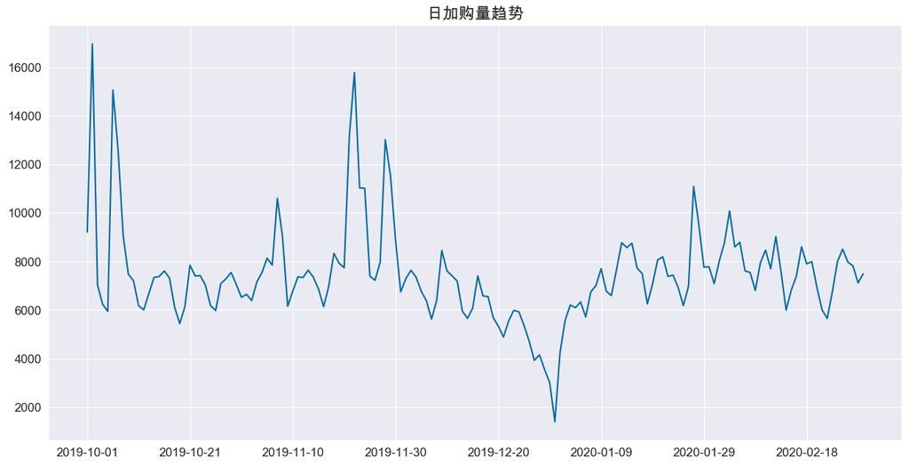

```python
df_addcart_date.index = df_addcart_date['date']
plt.figure(figsize=(15, 7.5), dpi=100)
df_addcart_date['count'].plot()
plt.title('日加购量趋势', size=16)
plt.xticks(size=12)
plt.yticks(size=12)
plt.xlabel('')
```

### 日客户加购转化率

明确日客户加购转化率定义：以天为周期，一个客户在一个周期内多次浏览仅算作一次（UV)，如果客户在周期内作出了加购行为（多次或一次），仅算一次加购。

```python
df_addcart_date = df_addcart_all[['user_id', 'date']]
df_addcart_date.head()
```

|  | user_id | date |
| --- | --- | --- |
| 0 | 2963072 | 2019-12-22 |
| 1 | 4661182 | 2019-12-22 |
| 2 | 5493470 | 2019-11-11 |
| 3 | 8846226 | 2019-10-01 |
| 4 | 8846226 | 2019-10-02 |

```python
# 计算每日客户浏览量数量
uv = df_uv_date.groupby('date', as_index=False).count()
# 计算每日加购数量
addcart = df_addcart_date.groupby('date', as_index=False).count()

uv_addcart = pd.merge(uv[['date', 'user_id']], addcart, on='date')
uv_addcart['conversion_rate'] = uv_addcart['user_id_y']/uv_addcart['user_id_x']

uv_addcart[uv_addcart['conversion_rate'] > 1.]
# 有异常转化率，需要去除
```

|  | date | user_id_x | user_id_y | conversion_rate |
| --- | --- | --- | --- | --- |
| 1 | 2019-10-02 | 9436 | 10735 | 1.137664 |
| 5 | 2019-10-06 | 8789 | 9177 | 1.044146 |

```python
uv_addcart.drop([1, 5], axis=0, inplace=True)
uv_addcart[uv_addcart['conversion_rate'] > 1.]
```

|  | date | user_id_x | user_id_y | conversion_rate |
| --- | --- | --- | --- | --- |

```python
uv_addcart.index = uv_addcart['date']
uv_addcart
```

| date | date | user_id_x | user_id_y | conversion_rate |
| --- | --- | --- | --- | --- |
| 2019-10-01 | 2019-10-01 | 6467 | 4133 | 0.639091 |
| 2019-10-03 | 2019-10-03 | 5800 | 2740 | 0.472414 |
| 2019-10-04 | 2019-10-04 | 5364 | 2290 | 0.426920 |
| 2019-10-05 | 2019-10-05 | 5085 | 2504 | 0.492429 |
| 2019-10-07 | 2019-10-07 | 8314 | 6654 | 0.800337 |
| ... | ... | ... | ... | ... |
| 2020-02-25 | 2020-02-25 | 7314 | 2997 | 0.409762 |
| 2020-02-26 | 2020-02-26 | 7109 | 2891 | 0.406668 |
| 2020-02-27 | 2020-02-27 | 7271 | 2927 | 0.402558 |
| 2020-02-28 | 2020-02-28 | 6791 | 2631 | 0.387425 |
| 2020-02-29 | 2020-02-29 | 6722 | 2561 | 0.380988 |

150 rows × 4 columns

```python
print('日均客户加购转化率为:', np.mean(uv_addcart['conversion_rate']))
print('日最大加购转化率为:{},日期是:{}'.format(max(
    uv_addcart['conversion_rate']), uv_addcart['date'][uv_addcart['conversion_rate'].argmax()]))
print('日最小加购转化率为:{},日期是:{}'.format(min(
    uv_addcart['conversion_rate']), uv_addcart['date'][uv_addcart['conversion_rate'].argmin()]))
```

```
日均客户加购转化率为: 0.41463301003493713
日最大加购转化率为:0.8003367813326918,日期是:2019-10-07
日最小加购转化率为:0.25335720680393914,日期是:2019-12-31
```

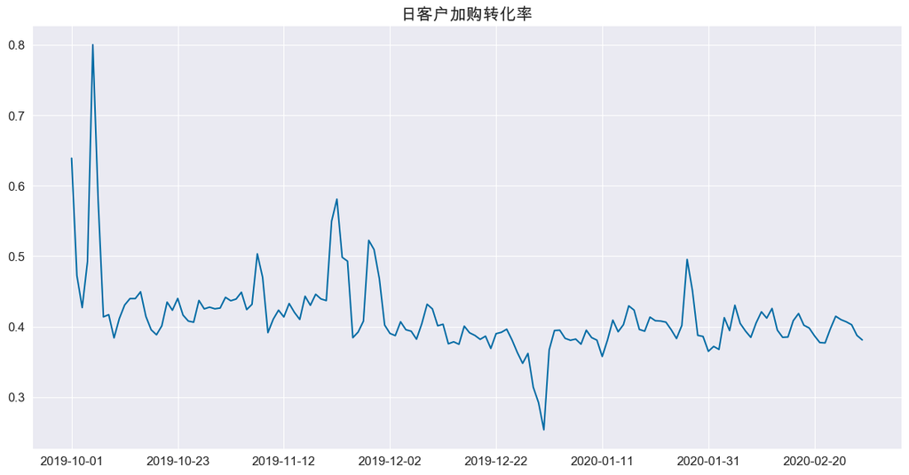

```python
plt.figure(figsize=(15, 7.5), dpi=100)
uv_addcart[['date', 'conversion_rate']].set_index(
    'date')['conversion_rate'].plot()
plt.title('日客户加购转化率', size=16)
plt.xticks(size=12)
plt.yticks(size=12)
plt.xlabel('')
```

```python
# uv_addcart.to_csv('uv_cart.csv')
```

从上图可以看出，加购转化率在十月初达到了近80%，远远高于平均水平，说明十月初的新客户吸引策略中应该包括了一些折扣政策，使得客户离购买更近了一步，新客户被折扣吸引后大大提高了加购转化率。十月份的加购率要高于后续月份，结合之前对客户人数的分析，十月的客户人数比2020年1月和2月都要低，但是前者加购转化率却明显高于后者，这说明前者的客户群体中对产品有加购意愿的人群占比应该要高于后者，这应该是新客户运营策略的结果。

黑色星期五期间，加购数量也达到了仅次于十月初的峰值，但是加购转化率的增加幅度却远不如十月初，这说明黑色星期五是存量客户多次加购导致的加购量高，在转化率和客户量上并没有提升，这也说明了十月初的加购量大是由于新用户增加导致的，而非加购次数多导致的。

### 客户购买次数

```python
df_purchase = df_sampled[df_sampled.event_type == 'purchase']
df_purchase_all = df_purchase[['user_id', 'date', 'event_type']].groupby(
    ['user_id', 'date'], as_index=False).count().rename(columns={'event_type': 'count'})
df_purchase_all
```

|  | user_id | date | count |
| --- | --- | --- | --- |
| 0 | 9794320 | 2019-11-25 | 1 |
| 1 | 10280338 | 2019-11-20 | 4 |
| 2 | 10280338 | 2019-11-21 | 1 |
| 3 | 10280338 | 2020-02-13 | 6 |
| 4 | 12055855 | 2019-12-20 | 1 |
| ... | ... | ... | ... |
| 103948 | 622045495 | 2020-02-29 | 5 |
| 103949 | 622046885 | 2020-02-29 | 1 |
| 103950 | 622065000 | 2020-02-29 | 1 |
| 103951 | 622065819 | 2020-02-29 | 1 |
| 103952 | 622066161 | 2020-02-29 | 2 |

103953 rows × 3 columns

```python
df_purchase_user = df_purchase_all.groupby('user_id').sum()
# df_purchase_user
max_id = df_addcart_user[df_addcart_user['count']
                         == max(df_addcart_user['count'])].index[0]
print('在201910-202002期间，客户总购买次数为:', sum(df_purchase_user['count']))
print('其中购买次数最多的客户为user_id={},购买了{}次'.format(
    max_id, max(df_purchase_user['count'])))
print('在718620位客户中，有{}位有过购买行为，人均购买次数为:%.2f'.format(df_purchase_user.shape[0]) % (
    sum(df_purchase_user['count'])/df_purchase_user.shape[0]))
print('整体加购至购买转化率为:{:.2f}'.format(
    df_purchase_user.shape[0]/df_addcart_user.shape[0]))
```

[output not shown]

```python
conversion_cart_to_purchase_all = df_purchase_user.shape[0] / \
    df_addcart_user.shape[0]
conversion_cart_to_purchase_all
```

```
0.31339760146083867
```

```python
% % sql
SELECT user_id, COUNT(*) AS `count`
FROM cosmetic
WHERE event_type = 'purchase'
GROUP BY user_id
ORDER BY 2 DESC
LIMIT 10
```

```
 * mysql+pymysql://root:***@localhost/cosmetic_e_commerce
10 rows affected.
```

| user_id | count |
| --- | --- |
| 480463194 | 127 |
| 469299888 | 119 |
| 556579890 | 104 |
| 381816972 | 98 |
| 601469771 | 94 |
| 557790271 | 91 |
| 517825140 | 90 |
| 473313149 | 89 |
| 566439116 | 87 |
| 575709540 | 84 |

### 日购买量趋势

```python
df_purchase_date = df_purchase_all[['date', 'count']].groupby('date').sum()
# df_purchase_date
print('日购买量最大为:{},日期为:{}'.format(max(
    df_purchase_date['count']), df_purchase_date.index[df_purchase_date['count'].argmax()]))
print('日购买量最小为:{},日期为:{}'.format(min(
    df_purchase_date['count']), df_purchase_date.index[df_purchase_date['count'].argmin()]))
```

```
日购买量最大为:4526,日期为:2019-11-22
日购买量最小为:224,日期为:2019-12-31
```

日购买量最大的十天：

```python
% % sql
SELECT date, COUNT(1) AS purchase_count
FROM cosmetic
WHERE event_type = 'purchase'
GROUP BY date
ORDER BY 2 DESC
LIMIT 10
```

```
 * mysql+pymysql://root:***@localhost/cosmetic_e_commerce
10 rows affected.
```

| date | purchase_count |
| --- | --- |
| 2019-11-22 | 4526 |
| 2019-11-24 | 4066 |
| 2020-01-27 | 3659 |
| 2019-11-29 | 3632 |
| 2019-11-28 | 3484 |
| 2020-01-28 | 3429 |
| 2019-11-08 | 3350 |
| 2019-11-07 | 3208 |
| 2019-11-21 | 3188 |
| 2019-11-23 | 3048 |

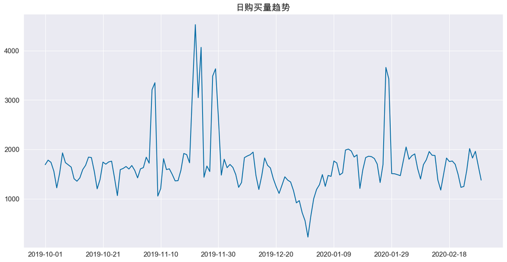

```python
plt.figure(figsize=(15, 7.5), dpi=100)
df_purchase_date['count'].plot()
plt.title('日购买量趋势', size=16)
plt.xticks(size=12)
plt.yticks(size=12)
plt.xlabel('')
```

### 日客户加购至购买转化率

明确日客户加购至购买转化率的定义：以天为周期，一个客户在周期内多次加购仅算做一次（UV)，如果客户在周期内作出了购买行为（一次或多次），仅算做一次购买。

```python
df_purchase_date = df_purchase_all[['user_id', 'date']]
df_purchase_date
```

|  | user_id | date |
| --- | --- | --- |
| 0 | 9794320 | 2019-11-25 |
| 1 | 10280338 | 2019-11-20 |
| 2 | 10280338 | 2019-11-21 |
| 3 | 10280338 | 2020-02-13 |
| 4 | 12055855 | 2019-12-20 |
| ... | ... | ... |
| 103948 | 622045495 | 2020-02-29 |
| 103949 | 622046885 | 2020-02-29 |
| 103950 | 622065000 | 2020-02-29 |
| 103951 | 622065819 | 2020-02-29 |
| 103952 | 622066161 | 2020-02-29 |

103953 rows × 2 columns

```python
# 计算每日购买量
purchase = df_purchase_date.groupby('date', as_index=False).count()
addcart_purchase = pd.merge(addcart, purchase, on='date')
addcart_purchase['conversion_rate'] = addcart_purchase['user_id_y'] / \
    addcart_purchase['user_id_x']
addcart_purchase.head()
```

|  | date | user_id_x | user_id_y | conversion_rate |
| --- | --- | --- | --- | --- |
| 0 | 2019-10-01 | 4133 | 663 | 0.160416 |
| 1 | 2019-10-02 | 10735 | 680 | 0.063344 |
| 2 | 2019-10-03 | 2740 | 707 | 0.258029 |
| 3 | 2019-10-04 | 2290 | 612 | 0.267249 |
| 4 | 2019-10-05 | 2504 | 491 | 0.196086 |

```python
# 无异常值
addcart_purchase[addcart_purchase['conversion_rate'] > 1.]
```

|  | date | user_id_x | user_id_y | conversion_rate |
| --- | --- | --- | --- | --- |

```python
print('日均客户加购至购买转化率为:', np.mean(addcart_purchase['conversion_rate']))
print('日最大加购至购买转化率为:{},日期是:{}'.format(max(
    addcart_purchase['conversion_rate']), addcart_purchase['date'][addcart_purchase['conversion_rate'].argmax()]))
print('日最小加购至购买转化率为:{},日期是:{}'.format(min(
    addcart_purchase['conversion_rate']), addcart_purchase['date'][addcart_purchase['conversion_rate'].argmin()]))
```

```
日均客户加购至购买转化率为: 0.24920443934927022
日最大加购至购买转化率为:0.40010712372790574,日期是:2019-11-24
日最小加购至购买转化率为:0.06298354582107442,日期是:2019-10-06
```

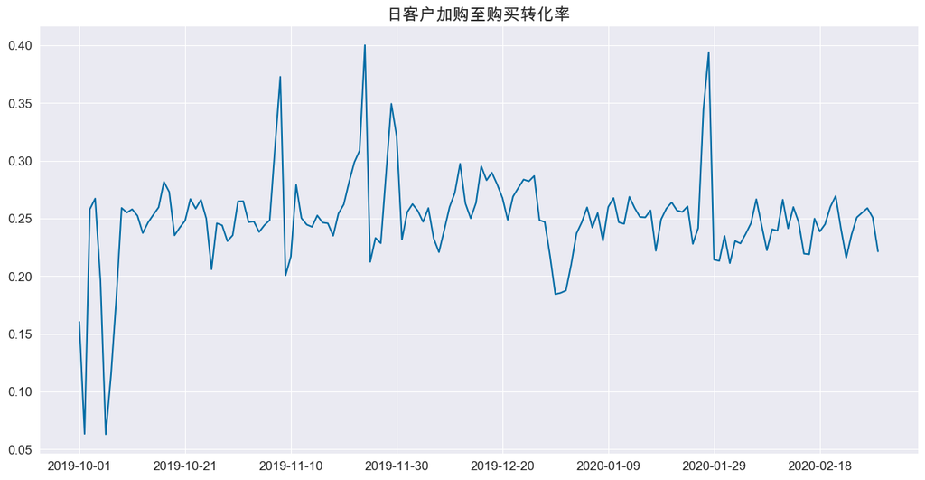

```python
plt.figure(figsize=(15, 7.5), dpi=100)
addcart_purchase[['date', 'conversion_rate']].set_index('date')[
    'conversion_rate'].plot()
plt.title('日客户加购至购买转化率', size=16)
plt.xticks(size=12)
plt.yticks(size=12)
plt.xlabel('')
```

```python
# addcart_purchase.to_csv('cart_purchase.csv')
```

从购买量和加购至购买转化率来看，十月初的新用户策略并没有带来购买量的提升，新客户被吸引只到加购这一步有明显的效果，但在最终的购买决策时却没有达到很好的效果。由于加购量大，购买量却没有显著提升，导致十月初的加购至购买转化率明显低于其他时间。

而在黑色星期五期间，达到了很好的购买量和客户购买转化率，这说明存量客户对最终的销售额有着更大的作用。

### 漏斗图

```python
conversion_view_to_cart_all, conversion_cart_to_purchase_all
```

```
(0.38884268972928715, 0.31339760146083867)
```

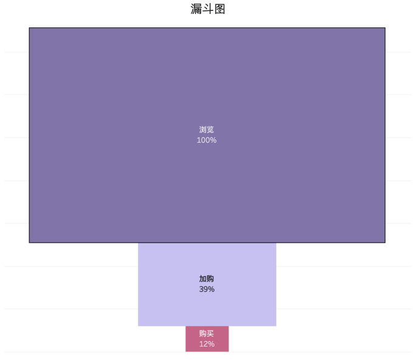

```python
img = plt.imread('faunnel.png')
plt.figure(figsize=(12, 16))
plt.imshow(img)
plt.grid('')
plt.axis('off')
plt.title('漏斗图', size=20)
```

可以看出，总体浏览至加购的转化情况很好，但还平台还需要考虑其他的运营策略提高加购至购买转化率，将流量转化为利润。

## 客户总体消费情况分析

```python
data_alls_purchase = df_purchase
```

### 销售总体指标

```python
# 销售总金额、总单数、总用户数
all_amount = data_alls_purchase.price.sum()
all_count = data_alls_purchase.price.count()
all_customers = len(data_alls_purchase.user_id.drop_duplicates())

print('*****销售总体指标*****')
print('销售总金额:', all_amount)
print('销售总单数:', all_count)
print('购买总人数:', all_customers)
```

```
*****销售总体指标*****
销售总金额: 1267872.16
销售总单数: 257315
购买总人数: 76202
```

### 每月消费趋势

```python
# 销售总金额、总单数、总人数的月趋势
month_amount = data_alls_purchase.price.sum()/5
month_count = data_alls_purchase.price.count()/5
month_customers = len(data_alls_purchase.user_id.drop_duplicates())/5

print('*****月均销售指标*****')
print('月均销售总金额:{:.2f}'.format(month_amount))
print('月均销售单数:', month_count)
print('月均购买总人数:', month_customers)
```

```
*****月均销售指标*****
月均销售总金额:253574.43
月均销售单数: 51463.0
月均购买总人数: 15240.4
```

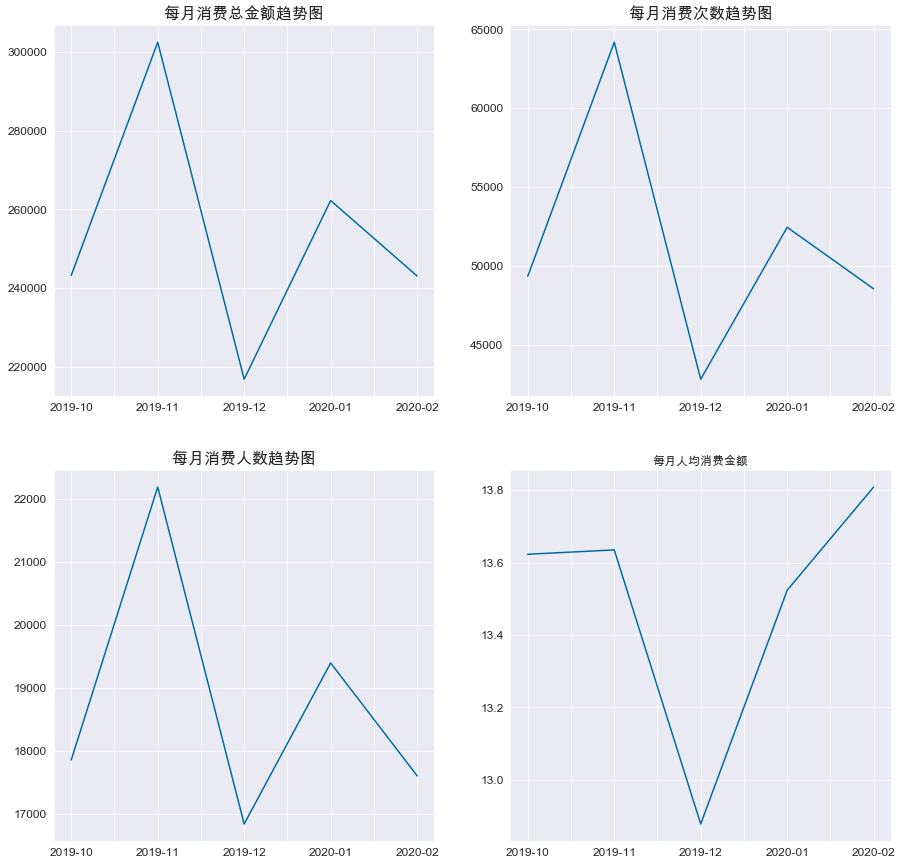

```python
fig, ax = plt.subplots(nrows=2, ncols=2, figsize=(15, 15))
ax1 = ax[0, 0]
ax2 = ax[0, 1]
ax3 = ax[1, 0]
ax4 = ax[1, 1]

# 客户每月消费金额趋势图
data_alls_purchase.groupby('year_month').price.sum().plot(ax=ax1)
ax1.tick_params(axis="x", labelsize=12)
ax1.tick_params(axis="y", labelsize=12)
ax1.set_xlabel('')
ax1.set_title('每月消费总金额趋势图', fontsize=16)

# 客户每月消费次数趋势图
data_alls_purchase.groupby('year_month').event_time.count().plot(ax=ax2)
ax2.tick_params(axis="x", labelsize=12)
ax2.tick_params(axis="y", labelsize=12)
ax2.set_xlabel('')
ax2.set_title('每月消费次数趋势图', fontsize=16)

# 每月消费人数趋势图
data_month_unique_user = data_alls_purchase.groupby(
    'year_month', as_index=False).user_id.nunique()
data_month_unique_user.index = data_month_unique_user['year_month']
data_month_unique_user.drop('year_month', axis=1, inplace=True)
data_month_unique_user.columns = ['user_count']
data_month_unique_user.plot(ax=ax3, legend=False)
ax3.tick_params(axis="x", labelsize=12)
ax3.tick_params(axis="y", labelsize=12)
ax3.set_xlabel('')
ax3.set_title('每月消费人数趋势图', fontsize=16)

# 每月人均消费金额
every_person_consume = data_alls_purchase.groupby('year_month').price.sum(
) / data_month_unique_user.unstack().groupby('year_month').sum()
every_person_consume.plot(ax=ax4)
ax4.set_title('每月人均消费金额')
ax4.tick_params(axis="x", labelsize=12)
ax4.tick_params(axis="y", labelsize=12)
ax4.set_xlabel('')
```

### 结论

从这几方面的数据来看，2019-10到2020-02这五个月消费情况变化幅度较大的是2019年11月，首先判断有可能是由于黑色星期五的影响，而获益于黑色星期五，消费总额，消费次数，消费人数都大幅度提升，但人均消费提升幅度很小，即人均的消费情况并没有受到黑色星期五的影响高。

## 客户个体消费情况分析

### 人均消费金额与消费次数

```python
# 人均消费金额、人均消费次数、人均客单价
user_consumption = data_alls_purchase.groupby('user_id').price.sum()
user_ord_count = data_alls_purchase.groupby('user_id').price.count()


# 人均消费金额与人均消费次数
data_user_average = data_alls_purchase.pivot_table(index='user_id', values=[
                                                   'price', 'event_time'], aggfunc={'price': 'sum', 'event_time': 'count'})

# 人均每单消费金额 pct: per customer transaction
data_user_average.columns = ['purchase_count', 'total_amount']
data_user_average['pct'] = data_user_average['total_amount'] / \
    data_user_average['purchase_count']
data_user_average
```

| user_id | purchase_count | total_amount | pct |
| --- | --- | --- | --- |
| 9794320 | 1 | 5.24 | 5.240000 |
| 10280338 | 11 | 20.20 | 1.836364 |
| 12055855 | 1 | 5.48 | 5.480000 |
| 15400971 | 1 | 6.19 | 6.190000 |
| 15781728 | 1 | 0.79 | 0.790000 |
| ... | ... | ... | ... |
| 622045495 | 5 | 8.70 | 1.740000 |
| 622046885 | 1 | 6.03 | 6.030000 |
| 622065000 | 1 | 4.38 | 4.380000 |
| 622065819 | 1 | 11.90 | 11.900000 |
| 622066161 | 2 | 9.03 | 4.515000 |

76202 rows × 3 columns

```python
data_user_average.describe()
```

|  | purchase_count | total_amount | pct |
| --- | --- | --- | --- |
| count | 76202.000000 | 76202.000000 | 76202.000000 |
| mean | 3.376749 | 16.638306 | 6.085817 |
| std | 4.304186 | 25.342573 | 9.850384 |
| min | 1.000000 | 0.000000 | 0.000000 |
| 25% | 1.000000 | 4.570000 | 2.400000 |
| 50% | 2.000000 | 9.370000 | 3.970000 |
| 75% | 4.000000 | 18.880000 | 6.330000 |
| max | 127.000000 | 846.840000 | 299.810000 |

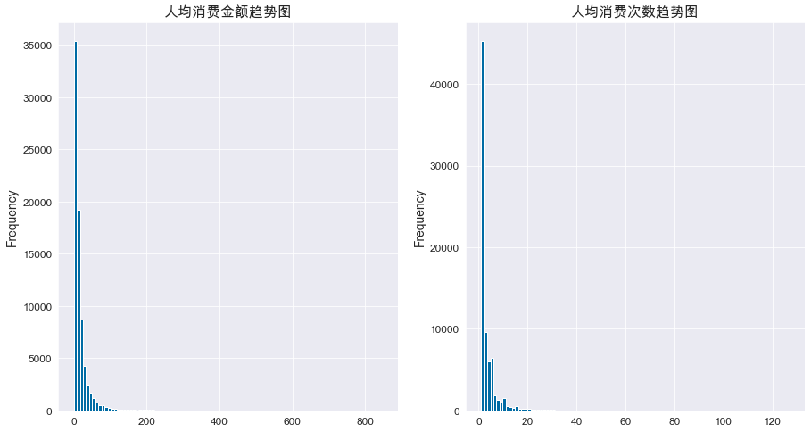

```python
fig, ax = plt.subplots(nrows=1, ncols=2, figsize=(15, 8))
ax1 = ax[0]
ax2 = ax[1]

# 人均消费金额趋势图
user_consumption.plot.hist(bins=100, ax=ax1)
ax1.tick_params(axis="x", labelsize=12)
ax1.tick_params(axis="y", labelsize=12)
ax1.set_xlabel('')
ax1.set_title('人均消费金额趋势图', fontsize=16)
ax1.set_ylabel('Frequency', fontsize=14)

# 客户人均消费次数趋势图
user_ord_count.plot.hist(bins=100, ax=ax2)
ax2.tick_params(axis="x", labelsize=12)
ax2.tick_params(axis="y", labelsize=12)
ax2.set_xlabel('')
ax2.set_title('人均消费次数趋势图', fontsize=16)
ax2.set_ylabel('Frequency', fontsize=14)
```

```python
# user_consumption.to_csv('user_consumption.csv')
# user_ord_count.to_csv('user_ord_count.csv')
```

一共有76202个客户，在消费次数上看，趋势是集中消费（少部分多消费），在消费金额上看，五个月总人均消费为16.638306，接近75%的用户低于平均值，而从std,min,max的区别可以看出客户的个体差异非常大，逐步判断大致服从二八法则，下面作出消费金额二八法则图。

```python
# 消费金额二八法则图
user_consumption = data_alls_purchase.groupby(
    'user_id')['price'].sum().sort_values().reset_index()  # 升序且保持原索引
# 累加
user_consumption['consumption_amount'] = user_consumption['price'].cumsum()
consumption_amount_total = user_consumption['consumption_amount'].max()
user_consumption['prop'] = user_consumption['consumption_amount'] / \
    consumption_amount_total
user_consumption.tail()
```

|  | user_id | price | consumption_amount | prop |
| --- | --- | --- | --- | --- |
| 76197 | 550009641 | 621.34 | 1264967.87 | 0.997709 |
| 76198 | 612148090 | 650.64 | 1265618.51 | 0.998222 |
| 76199 | 486366816 | 659.48 | 1266277.99 | 0.998743 |
| 76200 | 150318419 | 747.33 | 1267025.32 | 0.999332 |
| 76201 | 531900924 | 846.84 | 1267872.16 | 1.000000 |

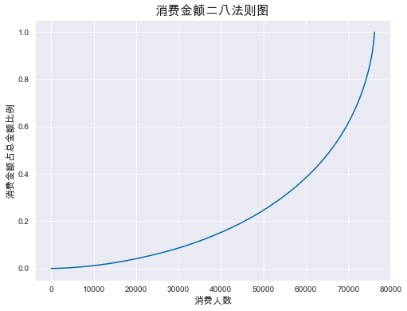

```python
plt.figure(figsize=(8, 6))
user_consumption.prop.plot()
plt.title('消费金额二八法则图', size=16)
plt.xlabel('消费人数', size=12)
plt.ylabel('消费金额占总金额比例', size=12)
```

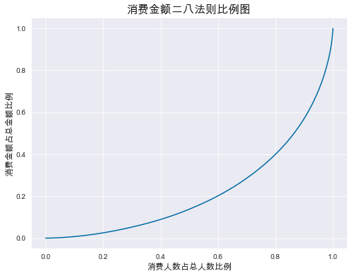

```python
# 消费金额二八法则比例图
data_user = data_alls_purchase.groupby(
    'user_id').price.sum().sort_values().reset_index()
user_sort = data_user['price'].cumsum()/data_user['price'].sum()
index = user_sort.index/len(user_sort)
user_sort.index = index
plt.figure(figsize=(8, 6))
plt.title('消费金额二八法则比例图', size=16)
plt.xlabel('消费人数占总人数比例', size=12)
plt.ylabel('消费金额占总金额比例', size=12)
user_sort.plot()
```

```python
# user_sort.to_csv('user_consumption_28.csv')
```

```python
# 求客单价
data_year_month_user = data_alls_purchase.groupby(
    ['year_month', 'user_id']).price.sum().reset_index()
data_year_month_user['order_count'] = data_alls_purchase.groupby(
    ['year_month', 'user_id']).price.count().reset_index()['price']
data_year_month_user['pct'] = data_year_month_user['price'] / \
    data_year_month_user['order_count']
data_year_month_user.groupby('year_month')['pct'].sum()
```

```
year_month
2019-10    106537.671819
2019-11    127666.720530
2019-12    103717.454704
2020-01    117111.441895
2020-02    106747.153066
Name: pct, dtype: float64
```

```
每月人均消费金额： year_month
2019-10    13.622868
2019-11    13.634866
2019-12    12.878028
2020-01    13.523457
2020-02    13.808578
dtype: float64
每月人均消费次数: year_month
2019-10    2.763470
2019-11    2.892905
2019-12    2.542496
2020-01    2.704326
2020-02    2.757698
dtype: float64
每月人均客单价: year_month
2019-10    5.967160
2019-11    5.754382
2019-12    6.160091
2020-01    6.038851
2020-02    6.064490
dtype: float64
```

[figure not shown]

```python
# 人均消费趋势
fig, ax = plt.subplots(nrows=1, ncols=3, figsize=(15, 7.5))
ax1 = ax[0]
ax2 = ax[1]
ax3 = ax[2]


# 作出每月人均消费金额的趋势图
print('每月人均消费金额：', data_alls_purchase.groupby('year_month')
      ['price'].sum()/data_month_unique_user.iloc[:, 0])
(data_alls_purchase.groupby('year_month')[
 'price'].sum()/data_month_unique_user.iloc[:, 0]).plot(ax=ax1)
ax1.set_title('每月人均消费金额趋势图')

# 作出每月人均消费次数的趋势图
print('每月人均消费次数:', data_alls_purchase.groupby('year_month')
      ['user_id'].count()/data_month_unique_user.iloc[:, 0])
(data_alls_purchase.groupby('year_month')[
 'user_id'].count()/data_month_unique_user.iloc[:, 0]).plot(ax=ax2)
ax2.set_title('每月人均消费次数趋势图')

# 作出每月客单价的趋势图
print('每月人均客单价:', data_year_month_user.groupby('year_month')
      ['pct'].sum()/data_month_unique_user.iloc[:, 0])
(data_alls_purchase.groupby('year_month')[
 'price'].sum()/data_month_unique_user.iloc[:, 0]).plot(ax=ax3)
ax3.set_title('每月人均客单价趋势图')
ax1.set_xlabel('')
ax2.set_xlabel('')
ax3.set_xlabel('')
```

## 客户消费行为分析

以天为单位，从时间分布，重要购物行为以及消费产品的特性去分析客户消费行为，以此来了解客户。

### 购物时间分布

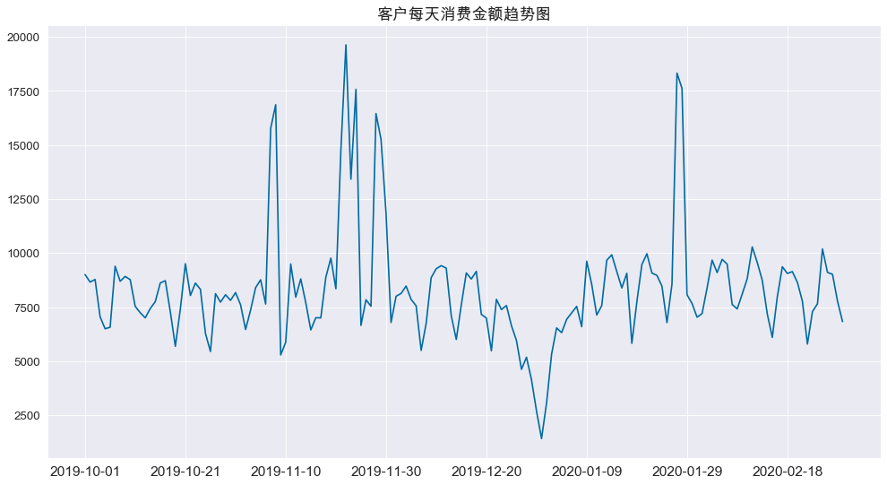

```python
# 查看客户消费金额的时间分布情况
plt.figure(figsize=(15, 8), dpi=80)
data_all_date = data_alls_purchase.groupby('date')['price'].sum()
data_all_date.plot()
plt.title('客户每天消费金额趋势图', size=16)
plt.xlabel("")
plt.xticks(size=14)
plt.yticks(size=12)
```

```python
# 消费金额描述统计
data_all_date.describe()
```

```
count      152.000000
mean      8341.264211
std       2673.626330
min       1420.220000
25%       7050.302500
50%       7974.055000
75%       9060.572500
max      19634.280000
Name: price, dtype: float64
```

```python
# 消费额最大的日期
data_all_date.idxmax()
```

```
'2019-11-22'
```

```python
# 消费额最小的日期
data_all_date.idxmin()
```

```
'2019-12-31'
```

```python
# 消费额前十名的日期
```

```python
% % sql
SELECT date, SUM(price) AS sale_amount
FROM cosmetic
WHERE event_type = 'purchase'
GROUP BY date
ORDER BY 2 DESC
LIMIT 10
```

```
 * mysql+pymysql://root:***@localhost/cosmetic_e_commerce
10 rows affected.
```

| date | sale_amount |
| --- | --- |
| 2019-11-22 | 19634.280000000006 |
| 2020-01-27 | 18325.500000000025 |
| 2020-01-28 | 17617.980000000025 |
| 2019-11-24 | 17576.830000000064 |
| 2019-11-08 | 16863.10000000004 |
| 2019-11-28 | 16454.71999999999 |
| 2019-11-07 | 15766.89 |
| 2019-11-29 | 15264.040000000072 |
| 2019-11-21 | 14770.360000000046 |
| 2019-11-23 | 13417.300000000023 |

```python
# 消费额后十名的日期
```

```python
% % sql
SELECT date, SUM(price) AS sale_amount
FROM cosmetic
WHERE event_type = 'purchase'
GROUP BY date
ORDER BY 2
LIMIT 10
```

```
 * mysql+pymysql://root:***@localhost/cosmetic_e_commerce
10 rows affected.
```

| date | sale_amount |
| --- | --- |
| 2019-12-31 | 1420.22 |
| 2019-12-30 | 2690.169999999999 |
| 2020-01-01 | 3066.0099999999998 |
| 2019-12-29 | 4134.299999999995 |
| 2019-12-27 | 4624.440000000007 |
| 2019-12-28 | 5185.84 |
| 2019-11-09 | 5289.68999999999 |
| 2020-01-02 | 5324.05 |
| 2019-10-26 | 5449.199999999985 |
| 2019-12-21 | 5480.029999999994 |

可以看到客户消费情况在均值附近波动，如有幅度较大的波动则是运营活动作用的结果；消费金额最大值大部分在黑色星期五附近，黑色星期五之前平台就已经开启了营销活动。金额最小值在12月31日附近，且靠近该日期附近的一个星期内消费金额都处于下降趋势，这是因为圣诞节开始，人们关注于置办其他商品，比如食品，礼物等，从而导致客户在化妆品上的消费能力下降。

### 重要消费行为分析

#### 首购与最后一次购买

```python
# 客户首购时间分布情况
user_first_buy = pd.DataFrame(data_alls_purchase.groupby(
    'user_id').date.min().value_counts().sort_index())
user_first_buy
```

|  | date |
| --- | --- |
| 2019-10-01 | 663 |
| 2019-10-02 | 676 |
| 2019-10-03 | 698 |
| 2019-10-04 | 595 |
| 2019-10-05 | 480 |
| ... | ... |
| 2020-02-25 | 449 |
| 2020-02-26 | 472 |
| 2020-02-27 | 454 |
| 2020-02-28 | 424 |
| 2020-02-29 | 338 |

152 rows × 1 columns

```python
% % sql
SELECT first_buy AS date, COUNT(user_id) AS first_buy_user_count
FROM
(SELECT user_id, MIN(date) AS first_buy
 FROM cosmetic
 WHERE event_type='purchase'
 GROUP BY user_id) AS tmp_table
GROUP BY first_buy
ORDER BY 1
LIMIT 10
```

```
 * mysql+pymysql://root:***@localhost/cosmetic_e_commerce
10 rows affected.
```

| date | first_buy_user_count |
| --- | --- |
| 2019-10-01 | 663 |
| 2019-10-02 | 676 |
| 2019-10-03 | 698 |
| 2019-10-04 | 595 |
| 2019-10-05 | 480 |
| 2019-10-06 | 562 |
| 2019-10-07 | 737 |
| 2019-10-08 | 687 |
| 2019-10-09 | 680 |
| 2019-10-10 | 620 |

```python
# 客户最后一购物时间分布
user_last_buy = pd.DataFrame(data_alls_purchase.groupby(
    'user_id').date.max().value_counts().sort_index())
user_last_buy
```

|  | date |
| --- | --- |
| 2019-10-01 | 413 |
| 2019-10-02 | 417 |
| 2019-10-03 | 455 |
| 2019-10-04 | 397 |
| 2019-10-05 | 314 |
| ... | ... |
| 2020-02-25 | 727 |
| 2020-02-26 | 720 |
| 2020-02-27 | 748 |
| 2020-02-28 | 653 |
| 2020-02-29 | 567 |

152 rows × 1 columns

```python
% % sql
SELECT last_buy AS date, COUNT(user_id) AS last_buy_user_count
FROM
(SELECT user_id, MAX(date) AS last_buy
 FROM cosmetic
 WHERE event_type='purchase'
 GROUP BY user_id) AS tmp_table
GROUP BY last_buy
ORDER BY 1
LIMIT 10
```

```
 * mysql+pymysql://root:***@localhost/cosmetic_e_commerce
10 rows affected.
```

| date | last_buy_user_count |
| --- | --- |
| 2019-10-01 | 413 |
| 2019-10-02 | 417 |
| 2019-10-03 | 455 |
| 2019-10-04 | 397 |
| 2019-10-05 | 314 |
| 2019-10-06 | 346 |
| 2019-10-07 | 485 |
| 2019-10-08 | 443 |
| 2019-10-09 | 456 |
| 2019-10-10 | 427 |

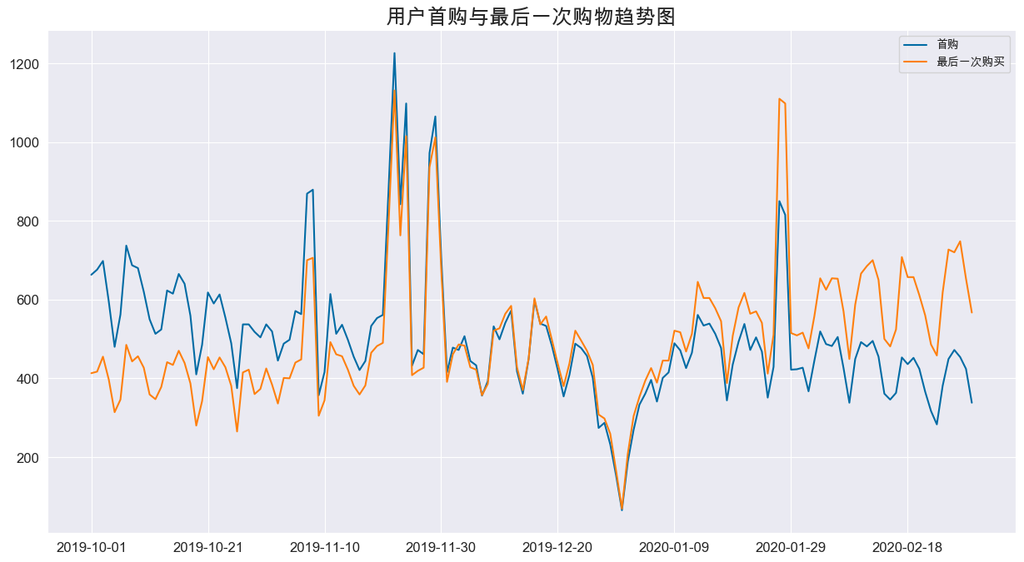

```python
# 用户首购与最后一次购物趋势图
plt.figure(figsize=(15, 8), dpi=100)
user_first_buy.date.plot(label='首购')
user_last_buy.date.plot(label='最后一次购买')
plt.legend()
plt.title('用户首购与最后一次购物趋势图', size=18)
plt.xticks(size=12)
plt.yticks(size=12)
```

可以发现首购与最后一次购物的时间分布图趋势几乎完全一致，猜测这里面重叠了许多客户首购就是最后一次购买。

查看首购即为最后一次购买的部分用户：

```python
% % sql
SELECT user_id, MIN(date) AS first_buy, MAX(date) AS last_buy
FROM cosmetic
WHERE event_type = 'purchase'
GROUP BY user_id
HAVING MIN(date) = MAX(date)
LIMIT 15
```

```
 * mysql+pymysql://root:***@localhost/cosmetic_e_commerce
15 rows affected.
```

| user_id | first_buy | last_buy |
| --- | --- | --- |
| 613411696 | 2020-02-18 | 2020-02-18 |
| 469049241 | 2020-01-19 | 2020-01-19 |
| 539154693 | 2020-01-28 | 2020-01-28 |
| 486725846 | 2019-10-03 | 2019-10-03 |
| 592327327 | 2020-02-12 | 2020-02-12 |
| 480708545 | 2019-11-26 | 2019-11-26 |
| 570218942 | 2019-11-11 | 2019-11-11 |
| 432466109 | 2020-01-21 | 2020-01-21 |
| 604567594 | 2020-01-22 | 2020-01-22 |
| 434587345 | 2020-01-26 | 2020-01-26 |
| 602777334 | 2020-02-28 | 2020-02-28 |
| 601881431 | 2020-01-16 | 2020-01-16 |
| 418572172 | 2019-11-04 | 2019-11-04 |
| 436109897 | 2020-02-25 | 2020-02-25 |
| 554541070 | 2019-12-16 | 2019-12-16 |

```python
# 将首次购物即为最后一次购物的客户挑出来
user_first = data_alls_purchase.groupby('user_id').date.min().reset_index()
user_last = data_alls_purchase.groupby('user_id').date.max().reset_index()
user_first_last = pd.merge(user_first, user_last,
                           left_on='user_id', right_on='user_id', how='inner')
user_first_last.columns = ['user_id', 'first', 'last']
user_first_last.head()
```

|  | user_id | first | last |
| --- | --- | --- | --- |
| 0 | 9794320 | 2019-11-25 | 2019-11-25 |
| 1 | 10280338 | 2019-11-20 | 2020-02-13 |
| 2 | 12055855 | 2019-12-20 | 2019-12-20 |
| 3 | 15400971 | 2019-12-13 | 2019-12-13 |
| 4 | 15781728 | 2019-11-16 | 2019-11-16 |

```python
user_first_last['comparison'] = (
    user_first_last['first'] == user_first_last['last'])
user_first_last.head()
```

|  | user_id | first | last | comparison |
| --- | --- | --- | --- | --- |
| 0 | 9794320 | 2019-11-25 | 2019-11-25 | True |
| 1 | 10280338 | 2019-11-20 | 2020-02-13 | False |
| 2 | 12055855 | 2019-12-20 | 2019-12-20 | True |
| 3 | 15400971 | 2019-12-13 | 2019-12-13 | True |
| 4 | 15781728 | 2019-11-16 | 2019-11-16 | True |

```python
user_first_last['comparison'].value_counts()
```

```
True     61106
False    15096
Name: comparison, dtype: int64
```

共有61106位客户属于首购即尾购的情况。

```python
# 查看五个月时间里只购买一天就流失的客户占比
user_first_last['comparison'].value_counts()/len(user_first_last)
```

```
True     0.801895
False    0.198105
Name: comparison, dtype: float64
```

接近80%的用户在一天之内流失，可以看出流失率很高。

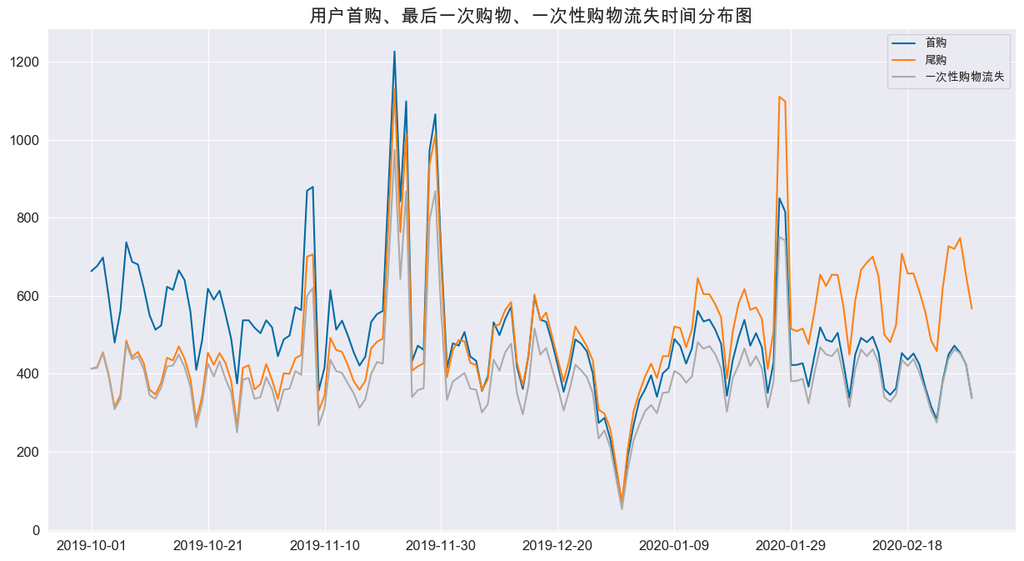

```python
# 绘制客户首购，尾购，以及一次性购物流失的时间趋势图
plt.figure(figsize=(15, 8), dpi=100)
user_first_buy.date.plot(label='首购')
user_last_buy.date.plot(label='尾购')
user_first_last[user_first_last['comparison'] ==
                True]['last'].value_counts().sort_index().plot(label='一次性购物流失')
plt.legend()
plt.title('用户首购、最后一次购物、一次性购物流失时间分布图', size=16)
plt.xticks(size=12)
plt.yticks(size=12)
```

三者数据极其相似，基本上流失的客户就是新增的客户，当天流入当天流失，流失比较严重。

```python
# user_first_last[user_first_last['comparison']==True]['last'].value_counts().sort_index().to_csv('user_first_last.csv')
# user_first_buy.to_csv('user_first.csv')
# user_last_buy.to_csv('user_last.csv')
```

再看一天购物流失客户与不是一天购物流失客户的消费能力对比，验证价格是不是导致客户流失的原因。

```python
user_lost_ing = pd.merge(data_alls_purchase[['user_id', 'price']], user_first_last[[
                         'user_id', 'comparison']], left_on='user_id', right_on='user_id', how='inner')
user_lost = user_lost_ing[user_lost_ing.comparison == True]
user_lost
```

|  | user_id | price | comparison |
| --- | --- | --- | --- |
| 0 | 613411696 | 4.83 | True |
| 1 | 613411696 | 1.43 | True |
| 2 | 613411696 | 1.43 | True |
| 3 | 613411696 | 4.76 | True |
| 4 | 613411696 | 3.97 | True |
| ... | ... | ... | ... |
| 257310 | 557329628 | 18.25 | True |
| 257311 | 79645599 | 0.87 | True |
| 257312 | 532027557 | 1.73 | True |
| 257313 | 509079943 | 7.94 | True |
| 257314 | 307430052 | 2.86 | True |

140007 rows × 3 columns

```python
user_lost_desc = user_lost.groupby('user_id').price.agg(['sum', 'count'])
user_lost_desc['amount'] = user_lost_desc['sum']/user_lost_desc['count']
user_lost_desc
```

| user_id | sum | count | amount |
| --- | --- | --- | --- |
| 9794320 | 5.24 | 1 | 5.240 |
| 12055855 | 5.48 | 1 | 5.480 |
| 15400971 | 6.19 | 1 | 6.190 |
| 15781728 | 0.79 | 1 | 0.790 |
| 20554973 | 8.06 | 2 | 4.030 |
| ... | ... | ... | ... |
| 622045495 | 8.70 | 5 | 1.740 |
| 622046885 | 6.03 | 1 | 6.030 |
| 622065000 | 4.38 | 1 | 4.380 |
| 622065819 | 11.90 | 1 | 11.900 |
| 622066161 | 9.03 | 2 | 4.515 |

61106 rows × 3 columns

```python
# 查看一天购买流失客户的消费情况
user_lost_desc.describe()
```

|  | sum | count | amount |
| --- | --- | --- | --- |
| count | 61106.000000 | 61106.000000 | 61106.000000 |
| mean | 11.819943 | 2.291215 | 6.320247 |
| std | 16.661866 | 2.198112 | 10.690072 |
| min | 0.000000 | 1.000000 | 0.000000 |
| 25% | 3.920000 | 1.000000 | 2.323333 |
| 50% | 7.380000 | 2.000000 | 3.970000 |
| 75% | 14.107500 | 3.000000 | 6.469375 |
| max | 605.970000 | 61.000000 | 299.810000 |

```python
# 查看不是一天购买流失客户的消费情况
user_ing = user_lost_ing[user_lost_ing['comparison'] == False]
user_ing_desc = user_ing.groupby('user_id').price.agg(['sum', 'count'])
user_ing_desc['amount'] = user_ing_desc['sum']/user_ing_desc['count']
user_ing_desc.describe()
```

|  | sum | count | amount |
| --- | --- | --- | --- |
| count | 15096.000000 | 15096.000000 | 15096.000000 |
| mean | 36.142203 | 7.770800 | 5.136886 |
| std | 40.545085 | 7.062795 | 5.108300 |
| min | 0.460000 | 2.000000 | 0.230000 |
| 25% | 13.740000 | 4.000000 | 2.813286 |
| 50% | 24.595000 | 6.000000 | 4.040000 |
| 75% | 43.695000 | 10.000000 | 5.823500 |
| max | 846.840000 | 127.000000 | 194.440000 |

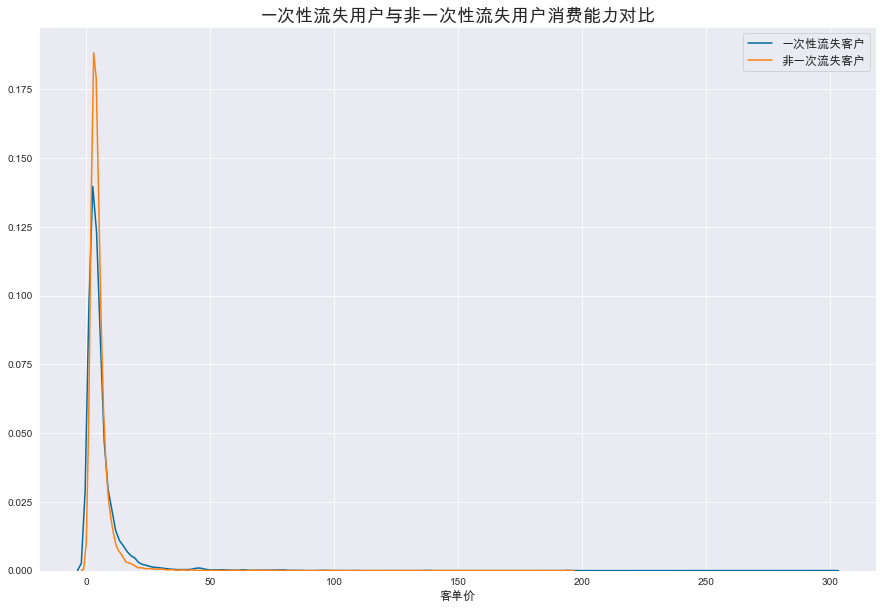

```python
plt.figure(figsize=(15, 10))
sns.kdeplot(user_lost_desc['amount'], label='一次性流失客户')
sns.kdeplot(user_ing_desc['amount'], label='非一次流失客户')
plt.legend(fontsize=12)
plt.xlabel('客单价', size=12)
plt.ylabel("")
plt.title('一次性流失用户与非一次性流失用户消费能力对比', size=18)
```

可以看出两类用户的分布情况大致相同，但非一次性消费用户在客单价相同情况下要更集中，这一结论也可以从描述性统计中的标准差得出。

#### 复购与回购

```python
# 查看每月复购率
user_month_count = data_alls_purchase.pivot_table(
    index='user_id', columns='year_month', values='event_time', aggfunc='count')
user_month_count = user_month_count.applymap(
    lambda x: 0 if x == 1. else 1 if x > 1 else np.nan)  # 整理复购情况,只购买一次为0，购买多次为1
user_month_count.sum()/user_month_count.count()
```

```
year_month
2019-10    0.604458
2019-11    0.624763
2019-12    0.564887
2020-01    0.604754
2020-02    0.596012
dtype: float64
```

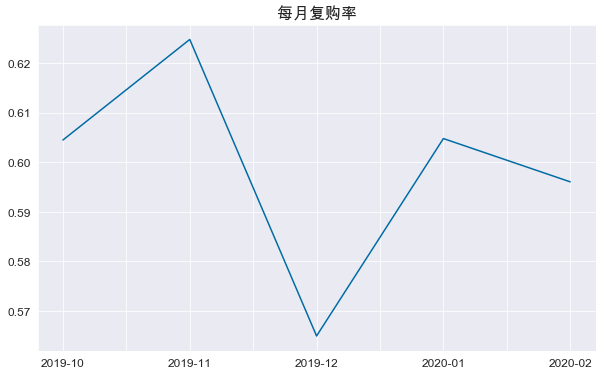

```python
plt.figure(figsize=(10, 6))
(user_month_count.sum()/user_month_count.count()).plot()
plt.xlabel('')
plt.title('每月复购率', size=16)
plt.xticks(size=12)
plt.yticks(size=12)
```

```python
print('月均复购率:{:.2f}%'.format(
    (user_month_count.sum()/user_month_count.count()).mean()*100))
```

```
月均复购率:59.90%
```

```python
# 查看每月单个用户是否有消费，是为1，否为0
user_month_counts = data_alls_purchase.pivot_table(
    index='user_id', columns='year_month', values='event_time', aggfunc='count').fillna(0)
user_month_counts_pivoted = user_month_counts.applymap(
    lambda x: 1 if x > 0 else 0)
user_month_counts_pivoted
```

| year_month user_id | 2019-10 | 2019-11 | 2019-12 | 2020-01 | 2020-02 |
| --- | --- | --- | --- | --- | --- |
| 9794320 | 0 | 1 | 0 | 0 | 0 |
| 10280338 | 0 | 1 | 0 | 0 | 1 |
| 12055855 | 0 | 0 | 1 | 0 | 0 |
| 15400971 | 0 | 0 | 1 | 0 | 0 |
| 15781728 | 0 | 1 | 0 | 0 | 0 |
| ... | ... | ... | ... | ... | ... |
| 622045495 | 0 | 0 | 0 | 0 | 1 |
| 622046885 | 0 | 0 | 0 | 0 | 1 |
| 622065000 | 0 | 0 | 0 | 0 | 1 |
| 622065819 | 0 | 0 | 0 | 0 | 1 |
| 622066161 | 0 | 0 | 0 | 0 | 1 |

76202 rows × 5 columns

```python
# 查看回购率:本月购买，下个月还购买算回购
def get_user_next_buy(data):
    status = []

    # 月份循环
    for i in range(4):

        # 1.本月无消费
        if data[i] == 0:
            status.append(np.nan)

        # 下个月有消费
        else:
            if data[i+1] == 1:
                status.append(1)

        # 下个月无消费
            else:
                status.append(0)

    status.append(np.nan)

    return status
```

```python
user_month_counts_get = user_month_counts_pivoted.apply(
    get_user_next_buy, axis=1)
user_month_counts_get = pd.DataFrame(user_month_counts_get, columns=['list'])
user_month_counts_get[['2019-10', '2019-11', '2019-12', '2020-01', '2020-02']
                      ] = pd.DataFrame(user_month_counts_get.list.to_list(), index=user_month_counts_get.index)
user_month_counts_get.drop('list', axis=1, inplace=True)
user_month_counts_get.sum()/user_month_counts_get.count()
```

```
2019-10    0.184160
2019-11    0.124718
2019-12    0.145038
2020-01    0.154437
2020-02         NaN
dtype: float64
```

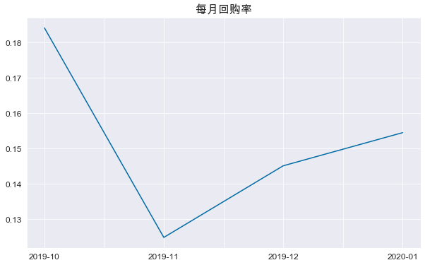

```python
plt.figure(figsize=(10, 6))
(user_month_counts_get.sum()/user_month_counts_get.count()).plot()
plt.xlabel('')
plt.title('每月回购率', size=16)
plt.xticks(size=12)
plt.yticks(size=12)
```

```python
print('月均回购率:{:.2f}%'.format(
    (user_month_counts_get.sum()/user_month_counts_get.count()).mean()*100))
```

```
月均回购率:15.21%
```

#### 人均每次购买量

```python
# 人均消费天数
user_consumption_days = data_alls_purchase.groupby(
    'user_id')['date'].apply(get_month_unique).unstack()
average_user_consumption_days = user_consumption_days.iloc[:, 0].sum(
)/all_customers
average_user_consumption_days
```

```
1.3641767932600195
```

```python
# 找不到代码了
print(inspect.getsource(get_month_unique))
```

```
def get_month_unique(data):
    a=data.duplicated()
    return a.value_counts()
```

```python
# 人均购买量（以天为单位）
all_count/all_customers/average_user_consumption_days
```

```
2.47530133810472
```

#### 小结

- 店铺的运营活动成功引流，指标峰值明显；但客户的质量不高，有近80%的客户为一次性购物后就消失，客户的忠诚度不高。
- 价格不是导致客户流失的主要原因。
- 客户喜欢一次性购买多件产品，复购率高达60%，但客户的回购率不高，只有15%左右。

### 基于客户生命周期观察客户结构

客户生命周期——新老活跃流失(不考虑2019年10月之前的情况）：

1. 本月无消费
   - 这个月是首月，则这个月是未注册
   - 上个月未注册，则这个月是未注册
   - 上个月是消费，则这个月是不活跃
   - 上个月是不活跃，则这个月是不活跃
2. 本月有消费
   - 上个月是未注册，则这个月是新客户
   - 上个月是消费，则这个月是活跃
   - 上个月是不活跃，则这个月是回流

```python
# pivot table查看客户在每个月的表现状态
user_active_counts=data_alls_purchase.pivot_table(index='user_id',
                                                  columns='year_month',
                                                  values='price',
                                                  aggfunc='count').fillna(0)
user_active_counts
```

| year_month user_id | 2019-10 | 2019-11 | 2019-12 | 2020-01 | 2020-02 |
| --- | --- | --- | --- | --- | --- |
| 9794320 | 0.0 | 1.0 | 0.0 | 0.0 | 0.0 |
| 10280338 | 0.0 | 5.0 | 0.0 | 0.0 | 6.0 |
| 12055855 | 0.0 | 0.0 | 1.0 | 0.0 | 0.0 |
| 15400971 | 0.0 | 0.0 | 1.0 | 0.0 | 0.0 |
| 15781728 | 0.0 | 1.0 | 0.0 | 0.0 | 0.0 |
| ... | ... | ... | ... | ... | ... |
| 622045495 | 0.0 | 0.0 | 0.0 | 0.0 | 5.0 |
| 622046885 | 0.0 | 0.0 | 0.0 | 0.0 | 1.0 |
| 622065000 | 0.0 | 0.0 | 0.0 | 0.0 | 1.0 |
| 622065819 | 0.0 | 0.0 | 0.0 | 0.0 | 1.0 |
| 622066161 | 0.0 | 0.0 | 0.0 | 0.0 | 2.0 |

76202 rows × 5 columns

```python
# 把每个月消费与不消费变为1与0，只需要知道是否消费
user_active_counts_new=user_active_counts.applymap(lambda x:1 if x>0 else 0)
user_active_counts_new
```

| year_month user_id | 2019-10 | 2019-11 | 2019-12 | 2020-01 | 2020-02 |
| --- | --- | --- | --- | --- | --- |
| 9794320 | 0 | 1 | 0 | 0 | 0 |
| 10280338 | 0 | 1 | 0 | 0 | 1 |
| 12055855 | 0 | 0 | 1 | 0 | 0 |
| 15400971 | 0 | 0 | 1 | 0 | 0 |
| 15781728 | 0 | 1 | 0 | 0 | 0 |
| ... | ... | ... | ... | ... | ... |
| 622045495 | 0 | 0 | 0 | 0 | 1 |
| 622046885 | 0 | 0 | 0 | 0 | 1 |
| 622065000 | 0 | 0 | 0 | 0 | 1 |
| 622065819 | 0 | 0 | 0 | 0 | 1 |
| 622066161 | 0 | 0 | 0 | 0 | 1 |

76202 rows × 5 columns

```python
# 由逻辑写出状态判断

def get_user_status(data):
    status=[]

    #根据月数写出循环迭代

    for i in range(5):

        #判断本月是否消费

        #1.本月未消费
        if data[i]==0:

            #不是首月
            if len(status)>0:
                if status[i-1]=='unreg':
                    status.append('unreg')  # 上个月未注册，则本月也是未注册

                else:
                    status.append('inactive') # 上月是消费或不活跃，则本月是不活跃

            #是首月
            else:
                status.append('unreg')    #首月未消费即未注册


        #2.本月有消费
        else:

            #不是首月
            if len(status)>0:

                if status[i-1]=='unreg':
                    status.append('new')    #上个月未注册，则这个月是新客户

                elif status[i-1]=='new':
                    status.append('active')  #上个月是新客户，则本月是活跃

                else:
                    status.append('return') # 上个月不活跃，则这个月是回流

            #是首月
            else:
                status.append('new') #首月消费即为新客户
    data.iloc[0:]=status

    return data
```

```python
# 得到客户每月状态
user_purchase_stats=user_active_counts_new.apply(get_user_status,axis=1)
user_purchase_stats
```

| year_month user_id | 2019-10 | 2019-11 | 2019-12 | 2020-01 | 2020-02 |
| --- | --- | --- | --- | --- | --- |
| 9794320 | unreg | new | inactive | inactive | inactive |
| 10280338 | unreg | new | inactive | inactive | return |
| 12055855 | unreg | unreg | new | inactive | inactive |
| 15400971 | unreg | unreg | new | inactive | inactive |
| 15781728 | unreg | new | inactive | inactive | inactive |
| ... | ... | ... | ... | ... | ... |
| 622045495 | unreg | unreg | unreg | unreg | new |
| 622046885 | unreg | unreg | unreg | unreg | new |
| 622065000 | unreg | unreg | unreg | unreg | new |
| 622065819 | unreg | unreg | unreg | unreg | new |
| 622066161 | unreg | unreg | unreg | unreg | new |

76202 rows × 5 columns

```python
# 将unreg调整为缺失值，方便计数(count不算缺失值)
purchase_stats_ct=user_purchase_stats.replace('unreg',np.nan).apply(lambda x:pd.value_counts(x))
purchase_stats_ct
```

| year_month | 2019-10 | 2019-11 | 2019-12 | 2020-01 | 2020-02 |
| --- | --- | --- | --- | --- | --- |
| active | NaN | 3288.0 | 1688 | 1066 | 1232 |
| inactive | NaN | 14566.0 | 32955 | 44549 | 58600 |
| new | 17854.0 | 18898.0 | 13040 | 14150 | 12260 |
| return | NaN | NaN | 2109 | 4177 | 4110 |

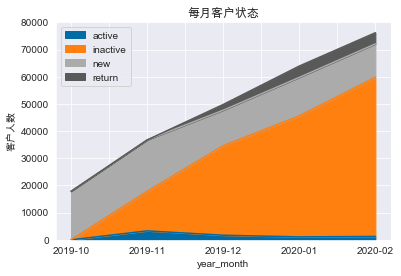

```python
# 制作面积图
plt.figure(figsize=(100,15),dpi=100)
purchase_stats_ct.fillna(0).T.plot.area()
plt.title('每月客户状态')
plt.ylabel('客户人数');
```

```python
#purchase_stats_ct.fillna(0).T.to_csv('purchase_area.csv')
```

```python
# 查看每月各类客户占比
purchase_stats_ct_rate=purchase_stats_ct.fillna(0).T.apply(lambda x:round((x/x.sum())*100,2),axis=1)
purchase_stats_ct_rate
```

| year_month | active | inactive | new | return |
| --- | --- | --- | --- | --- |
| 2019-10 | 0.00 | 0.00 | 100.00 | 0.00 |
| 2019-11 | 8.95 | 39.63 | 51.42 | 0.00 |
| 2019-12 | 3.39 | 66.19 | 26.19 | 4.24 |
| 2020-01 | 1.67 | 69.67 | 22.13 | 6.53 |
| 2020-02 | 1.62 | 76.90 | 16.09 | 5.39 |

从观察客户生命周期状态图可以看出活跃客户越来越少，流失客户越来越多。

## 基于RFM模型的客户分群

```python
# 获取R/F/M aka recency，frequency，monetary

rfm=data_alls_purchase.pivot_table(index='user_id',
                                   values={'event_time','price','user_session'},
                                   aggfunc={'event_time':'max',
                                            'price':'sum',
                                            'user_session':'count'})

rfm.head()
```

| user_id | event_time | price | user_session |
| --- | --- | --- | --- |
| 9794320 | 2019-11-25 05:07:13 | 5.24 | 1 |
| 10280338 | 2020-02-13 21:25:18 | 20.20 | 11 |
| 12055855 | 2019-12-20 12:05:29 | 5.48 | 1 |
| 15400971 | 2019-12-13 12:32:31 | 6.19 | 1 |
| 15781728 | 2019-11-16 23:37:59 | 0.79 | 1 |

```python
# 固定节点时间为2020年3月1日
rfm['R']=(pd.to_datetime('2020-3-1')-pd.to_datetime(rfm.event_time)).dt.days
rfm.rename(columns={'user_session':'F',
                    'price':'M'},inplace=True)
rfm.drop('event_time',axis=1,inplace=True)
rfm.head()
```

| user_id | M | F | R |
| --- | --- | --- | --- |
| 9794320 | 5.24 | 1 | 96 |
| 10280338 | 20.20 | 11 | 16 |
| 12055855 | 5.48 | 1 | 71 |
| 15400971 | 6.19 | 1 | 78 |
| 15781728 | 0.79 | 1 | 105 |

查看分布情况：

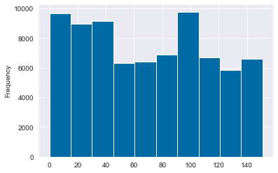

```python
rfm['R'].plot.hist();
```

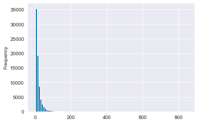

```python
rfm['M'].plot.hist(bins=100);
```

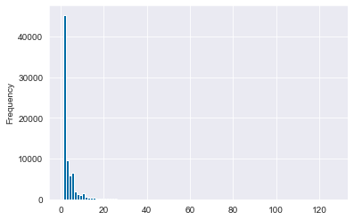

```python
rfm['F'].plot.hist(bins=100);
```

```python
rfm['R'].quantile(q=[0,0.5,0.75,1])
```

```
0.00      0.0
0.50     71.0
0.75    106.0
1.00    151.0
Name: R, dtype: float64
```

```python
rfm['M'].quantile(q=[0,0.5,0.75,1])
```

```
0.00      0.00
0.50      9.37
0.75     18.88
1.00    846.84
Name: M, dtype: float64
```

```python
rfm['F'].quantile(q=[0,0.5,0.75,1])
```

```
0.00      1.0
0.50      2.0
0.75      4.0
1.00    127.0
Name: F, dtype: float64
```

打分：

1. R：
   - R>=106, 1分
   - 71<=R<106, 2分
   - R<71, 3分
2. M：
   - M<=9.37, 1分
   - 9.37<M<=18.88, 2分
   - M>18.88, 3分
3. F：
   - F<=2, 1分
   - 2<F<=4, 2分
   - F>4, 3分

```python
def r_score(data):
    if data>=106:
        return 1
    elif data>=71 and data<106:
        return 2
    else :
        return 3
rfm['R_score']=rfm['R'].apply(r_score)
rfm.head()
```

| user_id | M | F | R | R_score |
| --- | --- | --- | --- | --- |
| 9794320 | 5.24 | 1 | 96 | 2 |
| 10280338 | 20.20 | 11 | 16 | 3 |
| 12055855 | 5.48 | 1 | 71 | 2 |
| 15400971 | 6.19 | 1 | 78 | 2 |
| 15781728 | 0.79 | 1 | 105 | 2 |

```python
def f_score(data):
    if data<=2:
        return 1
    elif data>2 and data<=4:
        return 2
    else:
        return 3

rfm['F_score']=rfm['F'].apply(f_score)
rfm.head()
```

| user_id | M | F | R | R_score | F_score |
| --- | --- | --- | --- | --- | --- |
| 9794320 | 5.24 | 1 | 96 | 2 | 1 |
| 10280338 | 20.20 | 11 | 16 | 3 | 3 |
| 12055855 | 5.48 | 1 | 71 | 2 | 1 |
| 15400971 | 6.19 | 1 | 78 | 2 | 1 |
| 15781728 | 0.79 | 1 | 105 | 2 | 1 |

```python
def m_score(data):

    if data<=9.37:
        return 1
    elif data>9.37 and data<=18.88:
        return 2
    else:
        return 3
rfm['M_score']=rfm['M'].apply(m_score)
rfm.head()
```

| user_id | M | F | R | R_score | F_score | M_score |
| --- | --- | --- | --- | --- | --- | --- |
| 9794320 | 5.24 | 1 | 96 | 2 | 1 | 1 |
| 10280338 | 20.20 | 11 | 16 | 3 | 3 | 3 |
| 12055855 | 5.48 | 1 | 71 | 2 | 1 | 1 |
| 15400971 | 6.19 | 1 | 78 | 2 | 1 | 1 |
| 15781728 | 0.79 | 1 | 105 | 2 | 1 | 1 |

```python
rfm.drop(['R','F','M'],axis=1,inplace=True)
rfm.head()
```

| user_id | R_score | F_score | M_score |
| --- | --- | --- | --- |
| 9794320 | 2 | 1 | 1 |
| 10280338 | 3 | 3 | 3 |
| 12055855 | 2 | 1 | 1 |
| 15400971 | 2 | 1 | 1 |
| 15781728 | 2 | 1 | 1 |

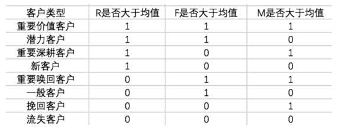

```python
img=plt.imread('Unknown-2.png')
plt.figure(figsize=(10,8))
plt.axis('off')
plt.imshow(img);
```

```python
# 给每条数据新增标签
def rfm_label(x):

    # level是字符型，可以直接合并
    level=x.apply(lambda x:'1' if x>=0 else '0')

    label=level.R_score+level.F_score+level.M_score

    Standard = {
        '111':'重要价值客户',
        '110':'消费潜力客户',
        '101':'频次深耕客户',
        '100':'新客户',
        '011':'重要价值流失预警客户',
        '010':'一般客户',
        '001':'高消费唤回客户',
        '000':'流失客户'
    }

    result=Standard.get(label)

    return result
```

```python
# 大于得分均值为1，小于为0
rfm['label']=rfm[['R_score','F_score','M_score']].apply(lambda x:x-x.mean()).apply(rfm_label,axis=1)
rfm.head()
```

| user_id | R_score | F_score | M_score | label |
| --- | --- | --- | --- | --- |
| 9794320 | 2 | 1 | 1 | 流失客户 |
| 10280338 | 3 | 3 | 3 | 重要价值客户 |
| 12055855 | 2 | 1 | 1 | 流失客户 |
| 15400971 | 2 | 1 | 1 | 流失客户 |
| 15781728 | 2 | 1 | 1 | 流失客户 |

```python
rfm.R_score.mean(),rfm.F_score.mean(),rfm.M_score.mean()
```

```
(2.2458334426917927, 1.6061783155297762, 1.7484842917508727)
```

```python
# 查看各层用户的RFM详细情况
rfm.groupby('label').sum()
```

| label | R_score | F_score | M_score |
| --- | --- | --- | --- |
| 一般客户 | 5207 | 7335 | 3425 |
| 新客户 | 43254 | 14418 | 14418 |
| 流失客户 | 25974 | 17545 | 17545 |
| 消费潜力客户 | 8472 | 6051 | 2824 |
| 重要价值客户 | 43182 | 37954 | 38097 |
| 重要价值流失预警客户 | 15908 | 25737 | 25820 |
| 频次深耕客户 | 18606 | 6202 | 14473 |
| 高消费唤回客户 | 10534 | 7152 | 16636 |

```python
# 查看各层客户的人数占比情况
rfm_percent = (rfm.groupby('label').R_score.count()/rfm.groupby('label').R_score.count().sum()*100).sort_values(ascending=False)
rfm_percent
```

```
label
流失客户          23.024330
新客户           18.920763
重要价值客户        18.889268
重要价值流失预警客户    13.440592
高消费唤回客户        9.385580
频次深耕客户         8.138894
一般客户           4.494633
消费潜力客户         3.705939
Name: R_score, dtype: float64
```

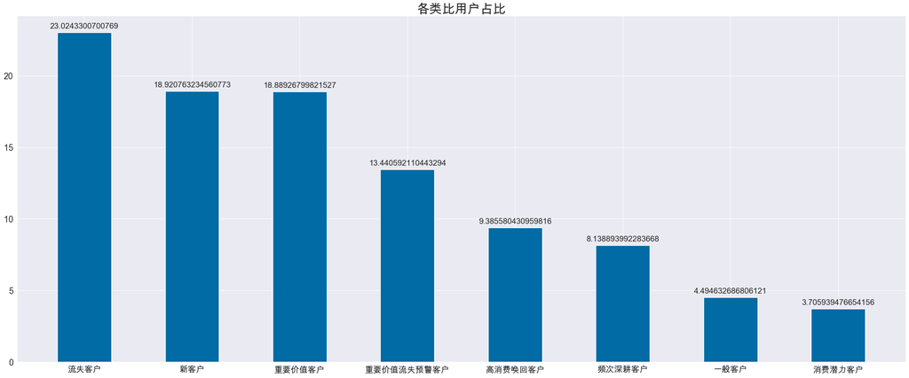

```python
plt.figure(figsize=(30,12),dpi=80)
rects=plt.bar(rfm_percent.index,rfm_percent.values,width=0.5)


for rect in rects:

    height=rect.get_height()

    plt.text(rect.get_x()+rect.get_width()/2,height+0.3,str(height),ha='center',size=15)

plt.xticks(size=16)
plt.yticks(size=16)
plt.title('各类比用户占比',size=24);
```

```python
#rfm.to_csv('rfm.csv')
```

```python
# 导出数据，下一步聚类分析
rfm_ml=data_alls_purchase.pivot_table(index='user_id',
                                   values={'event_time','price','user_session'},
                                   aggfunc={'event_time':'max',
                                            'price':'sum',
                                            'user_session':'count'})

rfm_ml['R']=(pd.to_datetime('2020-3-1')-pd.to_datetime(rfm_ml.event_time)).dt.days
rfm_ml.rename(columns={'user_session':'F',
                    'price':'M'},inplace=True)
rfm_ml.drop('event_time',axis=1,inplace=True)
rfm_ml.head()
```

| user_id | M | F | R |
| --- | --- | --- | --- |
| 9794320 | 5.24 | 1 | 96 |
| 10280338 | 20.20 | 11 | 16 |
| 12055855 | 5.48 | 1 | 71 |
| 15400971 | 6.19 | 1 | 78 |
| 15781728 | 0.79 | 1 | 105 |

```python
#rfm_ml.to_csv('rfm_ml.csv')
```

### K-Means聚类分析

分析过程与结果可见另一个notebook

## 消费产品维度分析

### 消费产品总体情况

```python
# 求出不同产品的消费总金额和购买总次数
test_category=data_alls_purchase.groupby('category_id').price.agg(['sum','count'])

# 求出产品单价
test_category['amount']=test_category['sum']/test_category['count']

#求出产品月均销售量
test_category['average_count']=test_category['count']/5
test_category.rename(columns={'sum':'消费总金额',
                              'count':'购买总次数',
                              'amount':'产品单价',
                              'average_count':'产品月均销售量'},inplace=True)

test_category.describe()
```

|  | 消费总金额 | 购买总次数 | 产品单价 | 产品月均销售量 |
| --- | --- | --- | --- | --- |
| count | 449.000000 | 449.000000 | 449.000000 | 449.000000 |
| mean | 2823.768731 | 573.084633 | 8.413239 | 114.616927 |
| std | 7322.478795 | 1413.874727 | 16.228092 | 282.774945 |
| min | 3.300000 | 1.000000 | 0.347922 | 0.200000 |
| 25% | 172.260000 | 33.000000 | 3.227089 | 6.600000 |
| 50% | 604.380000 | 135.000000 | 5.169163 | 27.000000 |
| 75% | 2156.030000 | 518.000000 | 8.186425 | 103.600000 |
| max | 85212.600000 | 16049.000000 | 209.525000 | 3209.800000 |

### 最喜爱产品的特征

```python
# 查看客户最喜爱消费前十的产品

test_category.sort_values(by='购买总次数',ascending=False)[:10]
```

| category_id | 消费总金额 | 购买总次数 | 产品单价 | 产品月均销售量 |
| --- | --- | --- | --- | --- |
| 1487580007675986893 | 20616.77 | 16049 | 1.284614 | 3209.8 |
| 1487580006317032337 | 35515.03 | 9956 | 3.567199 | 1991.2 |
| 1487580005092295511 | 85212.60 | 9143 | 9.319983 | 1828.6 |
| 1487580005595612013 | 26843.64 | 8828 | 3.040739 | 1765.6 |
| 1487580005671109489 | 21550.57 | 8725 | 2.469979 | 1745.0 |
| 1602943681873052386 | 37341.06 | 7252 | 5.149071 | 1450.4 |
| 1487580009286598681 | 4701.77 | 6768 | 0.694706 | 1353.6 |
| 1487580005268456287 | 52785.82 | 6064 | 8.704786 | 1212.8 |
| 1487580005134238553 | 13923.69 | 5217 | 2.668907 | 1043.4 |
| 1487580009445982239 | 8229.69 | 4755 | 1.730744 | 951.0 |

```python
# 最喜爱产品的描述性统计
test_category.sort_values(by='购买总次数',ascending=False)[:10].describe()
```

|  | 消费总金额 | 购买总次数 | 产品单价 | 产品月均销售量 |
| --- | --- | --- | --- | --- |
| count | 10.000000 | 10.000000 | 10.000000 | 10.000000 |
| mean | 30672.064000 | 8275.700000 | 3.863073 | 1655.140000 |
| std | 24012.056861 | 3239.863305 | 2.985859 | 647.972661 |
| min | 4701.770000 | 4755.000000 | 0.694706 | 951.000000 |
| 25% | 15596.960000 | 6240.000000 | 1.915553 | 1248.000000 |
| 50% | 24197.105000 | 7988.500000 | 2.854823 | 1597.700000 |
| 75% | 36884.552500 | 9064.250000 | 4.753603 | 1812.850000 |
| max | 85212.600000 | 16049.000000 | 9.319983 | 3209.800000 |

可以看到客户五个月以来产品的销售情况是:

[output not shown]

### 人均购买产品类数

```python
# 人均购买产品种类数
average_category=data_alls_purchase.groupby('user_id')['category_id'].apply(get_month_unique).unstack()
(average_category.sum()/all_customers)[0]
```

```
2.569223904884386
```

```python
#人均每次购买产品总类数
(average_category.sum()/all_customers)[0]/average_user_consumption_days
```

```
1.8833511298375225
```

### 小结

从产品维度上来看：

```
客户更喜欢低价产品

热销产品在长期来看并不热销

客户每次购买约2件产品
```